# Feature Engineering & EDA Assignment 5

Shiyu Hua

linked to assignment 2

### Oklahoma purchase credit card transactions project

The Office of Management and Enterprise Services in the State of Oklahoma has made its purchase credit card transactions available. This dataset contains information on purchases made through the purchase card programs administered by the state and higher education institutions.

- **[Section 1 Data Preparation](#1)**
  - 1.1 Create Data Fields
- **[Section 2 Initial observations](#2)**
- **[Section 3 Feature Engineering](#3)**
  - 3.1 Feature 1: The ratio to average amount
  - 3.2 Feature 2: The ratio to median amount
  - 3.3 Feature 3: The ratio to cardholder average amount
  - 3.4 Feature 4: The ratio to cardholder median amount
  - 3.5 Feature 5: The ratio to cardholder merchant average amount
  - 3.6 Feature 6: The ratio to cardholder merchant median amount
  - 3.7 Feature 7: The ratio to merchant average per month
  - 3.8 Feature 8: The ratio to merchant median per month
  - 3.9 Feature 9: The ratio to cardholder average per month
  - 3.10 Feature 10: The ratio to cardholder median per month
  - 3.11 Feature 11: The ratio to merchant average on the same day
  - 3.12 Feature 12: The ratio to merchant median on the same day
  - 3.13 Feature 13: The ratio to cardholder average on the same day
  - 3.14 Feature 14: The ratio to cardholder median on the same day
- **[Section 4 Modeling](#4)**
- **[Section 5 Summary](#5)**

## Section 1 Data Preparation

```python
import pandas as pd
path = 'C:/Users/lilyh/Desktop/final semester/5420/assignment2/'
df = pd.read_csv(path + 'res_purchase_card_(pcard)_fiscal_year_2014_3pcd-aiuu.csv') #, encoding = "ISO-8859-1")
df.head(5)
```

|  | Year-Month | Agency Number | Agency Name | Cardholder Last Name | Cardholder First Initial | Description | Amount | Vendor | Transaction Date | Posted Date | Merchant Category Code (MCC) |
| --- | --- | --- | --- | --- | --- | --- | --- | --- | --- | --- | --- |
| 0 | 201307 | 1000 | OKLAHOMA STATE UNIVERSITY | Mason | C | GENERAL PURCHASE | 890.00 | NACAS | 07/30/2013 12:00:00 AM | 07/31/2013 12:00:00 AM | CHARITABLE AND SOCIAL SERVICE ORGANIZATIONS |
| 1 | 201307 | 1000 | OKLAHOMA STATE UNIVERSITY | Mason | C | ROOM CHARGES | 368.96 | SHERATON HOTEL | 07/30/2013 12:00:00 AM | 07/31/2013 12:00:00 AM | SHERATON |
| 2 | 201307 | 1000 | OKLAHOMA STATE UNIVERSITY | Massey | J | GENERAL PURCHASE | 165.82 | SEARS.COM 9300 | 07/29/2013 12:00:00 AM | 07/31/2013 12:00:00 AM | DIRCT MARKETING/DIRCT MARKETERS--NOT ELSEWHERE... |
| 3 | 201307 | 1000 | OKLAHOMA STATE UNIVERSITY | Massey | T | GENERAL PURCHASE | 96.39 | WAL-MART #0137 | 07/30/2013 12:00:00 AM | 07/31/2013 12:00:00 AM | GROCERY STORES,AND SUPERMARKETS |
| 4 | 201307 | 1000 | OKLAHOMA STATE UNIVERSITY | Mauro-Herrera | M | HAMMERMILL COPY PLUS COPY EA | 125.96 | STAPLES DIRECT | 07/30/2013 12:00:00 AM | 07/31/2013 12:00:00 AM | STATIONERY, OFFICE SUPPLIES, PRINTING AND WRIT... |

```python
# check dimensions of the dataset, we found it has 442,458 rows and 11 columns
print(df.shape)
print(df.columns) # check column names
df.describe() # Get the Simple Summary Statistics
```

```
(442458, 11)
Index(['Year-Month', 'Agency Number', 'Agency Name', 'Cardholder Last Name',
       'Cardholder First Initial', 'Description', 'Amount', 'Vendor',
       'Transaction Date', 'Posted Date', 'Merchant Category Code (MCC)'],
      dtype='object')
```

|  | Year-Month | Agency Number | Amount |
| --- | --- | --- | --- |
| count | 442458.000000 | 442458.000000 | 4.424580e+05 |
| mean | 201357.284375 | 42785.860353 | 4.249912e+02 |
| std | 47.107417 | 33378.461293 | 5.266509e+03 |
| min | 201307.000000 | 1000.000000 | -4.286304e+04 |
| 25% | 201309.000000 | 1000.000000 | 3.091000e+01 |
| 50% | 201401.000000 | 47700.000000 | 1.048900e+02 |
| 75% | 201404.000000 | 76000.000000 | 3.450000e+02 |
| max | 201406.000000 | 98000.000000 | 1.903858e+06 |

```python
# change column names
df.columns = ['Year_Month', 'Agency_Number', 'Agency_Name', 'Cardholder_Last_Name',
      'Cardholder_First_Initial', 'Description', 'Amount', 'Vendor', 'Transaction_Date',
      'Posted_Date', 'Merchant_Category']
```

### 1.1 Create date fields

```python
#Creating separate Year and Month columns for future feature engineering
# Converting Transaction_Date and Posted_date from Python Object data type to datetime
df['Transaction_Date']=pd.to_datetime(df['Transaction_Date'])
df['Posted_Date']=pd.to_datetime(df['Posted_Date'])

df['Year_Month'].dtype
df['Year_Month']=pd.to_datetime(df['Year_Month'], format='%Y%m')
df['Year'] = df['Year_Month'].dt.year
df['Month'] = df['Year_Month'].dt.month
#Creating 'Week_Number' from 'Transaction_Date'
df['Week_Number'] = df['Transaction_Date'].dt.isocalendar().week

#Creating 'Day_of_Week' from 'Transaction_Date'
dayOfWeek={0:'Monday', 1:'Tuesday', 2:'Wednesday', 3:'Thursday', 4:'Friday', 5:'Saturday', 6:'Sunday'}
df['Day_of_Week'] = df['Transaction_Date'].dt.dayofweek.map(dayOfWeek)

df['Day_of_Week'].value_counts()
```

```
Wednesday    89644
Thursday     87537
Tuesday      86919
Friday       79917
Monday       61809
Saturday     26307
Sunday       10325
Name: Day_of_Week, dtype: int64
```

## Section 2 Initial observations

From the graph below, we can see Oklahoma State University has the most transactions, followed by University of Oklahoma.

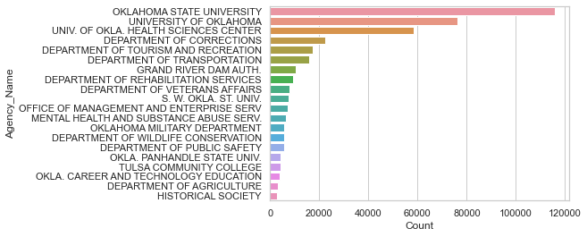

```python
import numpy as np
import plotly
import pandas as pd
import plotly.express as px

# Summarize the count statistics by agency_name in df_count
df_count = df['Agency_Name'].value_counts()
df_count = pd.DataFrame(df_count).reset_index()
df_count.columns = ['Agency_Name','Count']

fig = px.bar(df_count, x='Agency_Name', y='Count', color = 'Agency_Name', width=1000, height=400)
import seaborn as sns
sns.set_theme(style="whitegrid")
sns.barplot(y="Agency_Name", x="Count", data=df_count[0:20])
```

From the table below, we can see top two most transacted merchant categories are stationery and book stores.

```python
df['Merchant_Category'].value_counts()
```

```
STATIONERY, OFFICE SUPPLIES, PRINTING AND WRITING PAPER    24860
BOOK STORES                                                21981
INDUSTRIAL SUPPLIES NOT ELSEWHERE CLASSIFIED               21669
DENTAL/LABORATORY/MEDICAL/OPHTHALMIC HOSP EQIP AND SUP.    20183
GROCERY STORES,AND SUPERMARKETS                            17152
                                                           ...
MIDDLE EAST AIR                                                1
VIRGIN ATLANTIC                                                1
SWISS INTERNATIONAL AIR LINES                                  1
AMBULANCE SERVICES                                             1
COURT COST INCLUDING ALIMONY AND CHILD SUPPORT                 1
Name: Merchant_Category, Length: 435, dtype: int64
```

From the graph below, we can see that month October has the most transactions, followed by April and August.

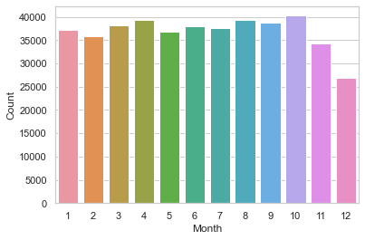

```python
# Summarize the count statistics by month in mon_count
mon_count = df['Month'].value_counts()
mon_count = pd.DataFrame(mon_count).reset_index()
mon_count.columns = ['Month','Count']

fig = px.bar(mon_count, x='Month', y='Count', color = 'Month', width=1000, height=400)
sns.set_theme(style="whitegrid")
sns.barplot(x="Month", y="Count", data=mon_count[0:12])
```

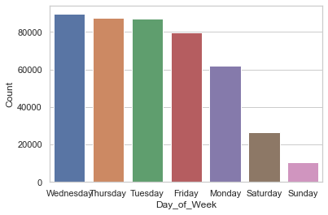

```python
week_count = df['Day_of_Week'].value_counts()
week_count = pd.DataFrame(week_count).reset_index()
week_count.columns = ['Day_of_Week','Count']

fig = px.bar(week_count, x='Day_of_Week', y='Count', color = 'Day_of_Week', width=1000, height=400)
sns.set_theme(style="whitegrid")
sns.barplot(x="Day_of_Week", y="Count", data=week_count[0:7])
```

From the graph below, we can see week 26 has the most transactions and the last week of year has the least transactions.

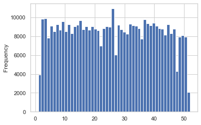

```python
df['Week_Number'].plot(kind = 'hist', bins = 52)
```

## Section 3 Feature Engineering

#### Instructions:

- Understand the data grain: each row is a cardholder (last name + first name)
- An agency can have multiple cardholders. A corporate card (agency_name) can be used by many cardholders and these cardholders have to follow the corporation policy.
- Intuition: One or two cardholders may abuse their corporate cards. If we compare a cardholder to his agency, we can find outliers.
- The spending for a merchant category can be higher than others. It does not make sense to compare the spending of a merchant category to another. An agency can spend on various merchant categories, and you cannot claim anomalies just because the spending on one merchant category is higher than another.
- Anomaly detection is about "comparing a transaction to a benchmark". What is the right benchmark?
- So we will aggregate to the Aggrecy_Name level and card holder level then build features.
- Common sense tells us the comparison should be at "Agency_Name" and "Merchant_Category" level.

### 3.1 Feature 1: The ratio to average amount

- Example given in class by prof

```python
# create average spending group by agency and merchant category
stat_by_agency = df.groupby(['Agency_Name', 'Merchant_Category'])['Amount'].mean()
stat_by_agency = pd.DataFrame(stat_by_agency)
stat_by_agency.columns = ['AVG_amount']
stat_by_agency
```

| Agency_Name | Merchant_Category | AVG_amount |
| --- | --- | --- |
| ARDMORE HIGHER EDUCATION CENTER | BUSINESS SERVICES NOT ELSEWHERE CLASSIFIED | 115.120000 |
|  | CATALOG MERCHANTS | -53.344286 |
|  | COMPUTER NETWORK/INFORMATION SERVICES | 18.340000 |
|  | DRUG STORES AND PHARMACIES | 153.450000 |
|  | GROCERY STORES,AND SUPERMARKETS | 74.525455 |
| ... | ... | ... |
| `DEPARTMENT OF EDUCATION | TELECOMMUNICATION SERVICES | 118.054000 |
|  | TRAVEL AGENCIES | 24.253731 |
|  | TROPICANA RESORT AND CASINO | 481.600000 |
|  | UNITED AIRLINES | 310.547368 |
|  | WYNDHAM HOTELS | 93.282857 |

8427 rows × 1 columns

```python
# add the new feature average spending to the dataset
df1 = pd.merge(df, stat_by_agency, how='left', on=['Agency_Name', 'Merchant_Category'])
# Feature 1: ratio of amount spending and average spending by merchant category
df1['agency_merchant_avg_ratio_amount'] = np.where(df1['AVG_amount']==0,0, df1['Amount'] / df1['AVG_amount'])
df1['agency_merchant_avg_ratio_amount'].describe()
```

```
count    442458.000000
mean          0.999724
std           7.225363
min       -2735.680000
25%           0.177145
50%           0.515301
75%           1.102916
max        2735.680000
Name: agency_merchant_avg_ratio_amount, dtype: float64
```

#### My thought process:

- The above percentile motivates me to cut by percentile for plotting
- Do you notice some transactions can be 2 times of the average. Could they be anomalies?

```python
# cut by percentile for plotting
var = 'agency_merchant_avg_ratio_amount'
binned_var = var + '_D'
percentile = [0,0.01,0.05,0.2,0.5,0.8,0.95,0.99,1]
df1[binned_var] = pd.qcut(df1[var],percentile)
df1[['agency_merchant_avg_ratio_amount_D']]
```

|  | agency_merchant_avg_ratio_amount_D |
| --- | --- |
| 0 | (1.298, 3.515] |
| 1 | (0.515, 1.298] |
| 2 | (0.133, 0.515] |
| 3 | (1.298, 3.515] |
| 4 | (0.133, 0.515] |
| ... | ... |
| 442453 | (0.515, 1.298] |
| 442454 | (0.133, 0.515] |
| 442455 | (0.0212, 0.133] |
| 442456 | (8.71, 2735.68] |
| 442457 | (1.298, 3.515] |

442458 rows × 1 columns

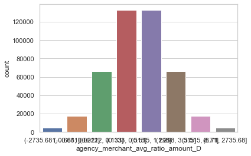

```python
sns.countplot(x="agency_merchant_avg_ratio_amount_D", data=df1)
```

#### Thought process:

- It will be ideal if the x label does not overlap with each other.
- Try to rotate it.

```
[Text(0, 0, '(-2735.681, -0.681]'),
```

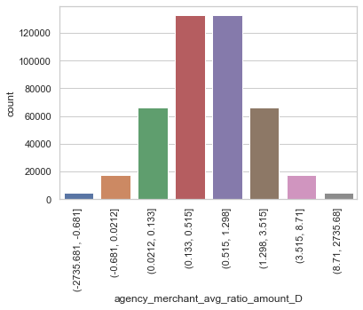

```python
import matplotlib.pyplot as plt
plt.figure(figsize=(6,4))
g = sns.countplot(x="agency_merchant_avg_ratio_amount_D", data=df1)
g.set_xticklabels(g.get_xticklabels(), rotation=90)
```

#### Thought process:

- Now we have identified extreme spending compared to the same merchant category.
- Take a look of them.

```python
df1[df1['agency_merchant_avg_ratio_amount']>2].head()
```

|  | Year_Month | Agency_Number | Agency_Name | Cardholder_Last_Name | Cardholder_First_Initial | Description | Amount | Vendor | Transaction_Date | Posted_Date | Merchant_Category | Year | Month | Week_Number | Day_of_Week | AVG_amount | agency_merchant_avg_ratio_amount | agency_merchant_avg_ratio_amount_D |
| --- | --- | --- | --- | --- | --- | --- | --- | --- | --- | --- | --- | --- | --- | --- | --- | --- | --- | --- |
| 0 | 2013-07-01 | 1000 | OKLAHOMA STATE UNIVERSITY | Mason | C | GENERAL PURCHASE | 890.00 | NACAS | 2013-07-30 | 2013-07-31 | CHARITABLE AND SOCIAL SERVICE ORGANIZATIONS | 2013 | 7 | 31 | Tuesday | 427.634060 | 2.081219 | (1.298, 3.515] |
| 16 | 2013-07-01 | 1000 | OKLAHOMA STATE UNIVERSITY | Mohiuddin | I | GENERAL PURCHASE | 2425.00 | WESTERN EQUIPMENT ALVA | 2013-07-29 | 2013-07-31 | HARDWARE STORES | 2013 | 7 | 31 | Monday | 170.060436 | 14.259636 | (8.71, 2735.68] |
| 17 | 2013-07-01 | 1000 | OKLAHOMA STATE UNIVERSITY | Mohiuddin | I | GENERAL PURCHASE | 2425.00 | WESTERN EQUIPMENT ALVA | 2013-07-29 | 2013-07-31 | HARDWARE STORES | 2013 | 7 | 31 | Monday | 170.060436 | 14.259636 | (8.71, 2735.68] |
| 33 | 2013-07-01 | 1000 | OKLAHOMA STATE UNIVERSITY | Gerlt | T | GENERAL PURCHASE | 3582.00 | TELVENT | 2013-07-26 | 2013-07-29 | BUSINESS SERVICES NOT ELSEWHERE CLASSIFIED | 2013 | 7 | 30 | Friday | 392.641168 | 9.122833 | (8.71, 2735.68] |
| 35 | 2013-07-01 | 1000 | OKLAHOMA STATE UNIVERSITY | GODSEY | R | GENERAL PURCHASE | 407.85 | OPTIMUM ENERGY PROD | 2013-07-26 | 2013-07-29 | HARDWARE STORES | 2013 | 7 | 30 | Friday | 170.060436 | 2.398265 | (1.298, 3.515] |

#### Thought Process:

- Now create a new dataframe that add the new features for future modeling and analysis

```python
df_complete = df.copy()
df_complete['agency_merchant_avg_ratio_amount'] = df1['agency_merchant_avg_ratio_amount']
```

##### Conclusion:

Extreme spendings can be detected from the ratio comparing the amount to the average amount spent on the same merchant category. The higher the ratio, the higher the likelihood of fraudulent transaction. The industry can determine appropriate benchmark ratio number for each merchant category.

### 3.2 Feature 2: The ratio to the median amount

- Notice the only difference to the above code is "median".
- The reason to use "median" is that median returns the central tendency for skewed number distributions. Extreme values (anomalies) can be detected by comparsion.

```python
# create median spending group by agency and merchant category
stat_by_agency = df.groupby(['Agency_Name', 'Merchant_Category'])['Amount'].median()
stat_by_agency = pd.DataFrame(stat_by_agency)
stat_by_agency.columns = ['Median_amount']
```

```python
# add the new feature median spending to the dataset
df2 = pd.merge(df, stat_by_agency, how='left', on=['Agency_Name', 'Merchant_Category'])
# Feature 2: ratio of amount spending and median spending by merchant category
df2['agency_merchant_median_ratio_amount'] = np.where(df2['Median_amount']==0,0, df2['Amount'] / df2['Median_amount'])
df2['agency_merchant_median_ratio_amount'].describe()
```

```
count    442458.000000
mean          4.952685
std        1078.581350
min       -1003.176471
25%           0.466090
50%           1.000000
75%           2.121102
max      528116.052705
Name: agency_merchant_median_ratio_amount, dtype: float64
```

```python
# cut by percentile for plotting
var = 'agency_merchant_median_ratio_amount'
binned_var = var + '_D'
percentile = [0,0.01,0.05,0.2,0.5,0.8,0.95,0.99,1]
df2[binned_var] = pd.qcut( df2[var],percentile)
```

```
[Text(0, 0, '(-1003.177, -1.121]'),
```

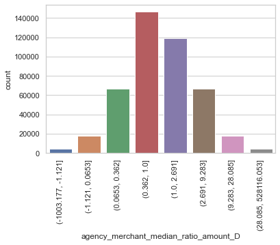

```python
import matplotlib.pyplot as plt
plt.figure(figsize=(6,4))
g = sns.countplot(x="agency_merchant_median_ratio_amount_D", data=df2)
g.set_xticklabels(g.get_xticklabels(), rotation=90)
```

```python
df2[df2['agency_merchant_median_ratio_amount']>2].head()
```

|  | Year_Month | Agency_Number | Agency_Name | Cardholder_Last_Name | Cardholder_First_Initial | Description | Amount | Vendor | Transaction_Date | Posted_Date | Merchant_Category | Year | Month | Week_Number | Day_of_Week | Median_amount | agency_merchant_median_ratio_amount | agency_merchant_median_ratio_amount_D |
| --- | --- | --- | --- | --- | --- | --- | --- | --- | --- | --- | --- | --- | --- | --- | --- | --- | --- | --- |
| 0 | 2013-07-01 | 1000 | OKLAHOMA STATE UNIVERSITY | Mason | C | GENERAL PURCHASE | 890.00 | NACAS | 2013-07-30 | 2013-07-31 | CHARITABLE AND SOCIAL SERVICE ORGANIZATIONS | 2013 | 7 | 31 | Tuesday | 250.000 | 3.560000 | (2.691, 9.283] |
| 3 | 2013-07-01 | 1000 | OKLAHOMA STATE UNIVERSITY | Massey | T | GENERAL PURCHASE | 96.39 | WAL-MART #0137 | 2013-07-30 | 2013-07-31 | GROCERY STORES,AND SUPERMARKETS | 2013 | 7 | 31 | Tuesday | 32.485 | 2.967216 | (2.691, 9.283] |
| 5 | 2013-07-01 | 1000 | OKLAHOMA STATE UNIVERSITY | Mauro-Herrera | M | GENERAL PURCHASE | 394.28 | KYOCERA DOCUMENT SOLUTION | 2013-07-29 | 2013-07-31 | OFFICE, PHOTOGRAPHIC, PHOTOCOPY, AND MICROFILM... | 2013 | 7 | 31 | Monday | 181.940 | 2.167088 | (1.0, 2.691] |
| 12 | 2013-07-01 | 1000 | OKLAHOMA STATE UNIVERSITY | McLemore | A | GENERAL PURCHASE | 572.27 | GIDDINGS MACHINE CO. | 2013-07-30 | 2013-07-31 | COMMERCIAL EQUIPMENT, NOT ELSEWHERE CLASSIFIED | 2013 | 7 | 31 | Tuesday | 187.000 | 3.060267 | (2.691, 9.283] |
| 14 | 2013-07-01 | 1000 | OKLAHOMA STATE UNIVERSITY | Meints | K | GENERAL PURCHASE | 445.00 | OK DEPT OF VO-TECH ED | 2013-07-30 | 2013-07-31 | GOVERNMENT SERVICES--NOT ELSEWHERE CLASSIFIED | 2013 | 7 | 31 | Tuesday | 91.500 | 4.863388 | (2.691, 9.283] |

```python
# add new feature to complete dataframe
df_complete['agency_merchant_median_ratio_amount'] = df2['agency_merchant_median_ratio_amount']
```

##### Conclusion:

Similar to the ratio to average amount, extreme spendings can be detected from the ratio comparing the amount to the median amount spent on the same merchant category. The median returns the central tendency for skewed number distributions so may be less affected by extreme outliers. The higher the ratio, the higher the likelihood of fraudulent transaction. The industry can determine appropriate benchmark ratio number for each merchant category.

### 3.3 Feature 3: The ratio to cardholder average amount

#### Thought process:

- From the intution that one or two cardholders may abuse their corporate cards, we can find outliers and anomalies from each cardholder and compare to his or her agency.
- So I aggregate at agency and cardholder level to compute the average amount spent and compare with transactions.
- The difference with feature 1 is changing "merchant category" to "cardholder".

```python
# create a new column cardholder_name
df['Cardholder_Name'] = df['Cardholder_Last_Name'] + " " + df['Cardholder_First_Initial']
# create average spending group by agency and cardholder
stat_by_agency = df.groupby(['Agency_Name', 'Cardholder_Name'])['Amount'].mean()
stat_by_agency = pd.DataFrame(stat_by_agency)
stat_by_agency.columns = ['cardholder_AVG_amount']
stat_by_agency
```

| Agency_Name | Cardholder_Name | cardholder_AVG_amount |
| --- | --- | --- |
| ARDMORE HIGHER EDUCATION CENTER | Pollard C | 124.993333 |
|  | Ray M | 91.013667 |
|  | Stoker C | 124.961154 |
| ATTORNEY GENERAL | Baustert J | 1367.959500 |
|  | Brown A | 179.335405 |
| ... | ... | ... |
| WORKERS COMPENSATION COURT | Eldred M | 111.756250 |
|  | Twyman V | 197.236667 |
| `DEPARTMENT OF EDUCATION | Bowman I | 498.400465 |
|  | Bryan J | 251.911960 |
|  | Ross P | 227.673400 |

5571 rows × 1 columns

```python
# add the new feature cardholder average spending to the dataset
df3 = pd.merge(df, stat_by_agency, how='left', on=['Agency_Name', 'Cardholder_Name'])
# Feature 3: ratio of amount spending and average spending by cardholder
df3['agency_cardholder_avg_ratio_amount'] = np.where(df3['cardholder_AVG_amount']==0,0, df3['Amount'] / df3['cardholder_AVG_amount'])
df3['agency_cardholder_avg_ratio_amount'].describe()
```

```
count    442458.000000
mean          0.999932
std           1.964953
min         -66.279236
25%           0.137960
50%           0.436545
75%           1.179746
max         112.838952
Name: agency_cardholder_avg_ratio_amount, dtype: float64
```

```python
# cut by percentile for plotting
var = 'agency_cardholder_avg_ratio_amount'
binned_var = var + '_D'
percentile = [0,0.01,0.05,0.2,0.5,0.8,0.95,0.99,1]
df3[binned_var] = pd.qcut(df3[var],percentile)
```

```
[Text(0, 0, '(-66.28, -0.653]'),
```

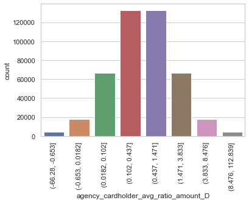

```python
import matplotlib.pyplot as plt
plt.figure(figsize=(6,4))
g = sns.countplot(x="agency_cardholder_avg_ratio_amount_D", data=df3)
g.set_xticklabels(g.get_xticklabels(), rotation=90)
```

```python
df3[df3['agency_cardholder_avg_ratio_amount']>2].head()
```

|  | Year_Month | Agency_Number | Agency_Name | Cardholder_Last_Name | Cardholder_First_Initial | Description | Amount | Vendor | Transaction_Date | Posted_Date | Merchant_Category | Year | Month | Week_Number | Day_of_Week | Cardholder_Name | cardholder_AVG_amount | agency_cardholder_avg_ratio_amount | agency_cardholder_avg_ratio_amount_D |
| --- | --- | --- | --- | --- | --- | --- | --- | --- | --- | --- | --- | --- | --- | --- | --- | --- | --- | --- | --- |
| 0 | 2013-07-01 | 1000 | OKLAHOMA STATE UNIVERSITY | Mason | C | GENERAL PURCHASE | 890.00 | NACAS | 2013-07-30 | 2013-07-31 | CHARITABLE AND SOCIAL SERVICE ORGANIZATIONS | 2013 | 7 | 31 | Tuesday | Mason C | 246.983846 | 3.603475 | (1.471, 3.833] |
| 5 | 2013-07-01 | 1000 | OKLAHOMA STATE UNIVERSITY | Mauro-Herrera | M | GENERAL PURCHASE | 394.28 | KYOCERA DOCUMENT SOLUTION | 2013-07-29 | 2013-07-31 | OFFICE, PHOTOGRAPHIC, PHOTOCOPY, AND MICROFILM... | 2013 | 7 | 31 | Monday | Mauro-Herrera M | 93.818028 | 4.202604 | (3.833, 8.476] |
| 12 | 2013-07-01 | 1000 | OKLAHOMA STATE UNIVERSITY | McLemore | A | GENERAL PURCHASE | 572.27 | GIDDINGS MACHINE CO. | 2013-07-30 | 2013-07-31 | COMMERCIAL EQUIPMENT, NOT ELSEWHERE CLASSIFIED | 2013 | 7 | 31 | Tuesday | McLemore A | 112.021232 | 5.108585 | (3.833, 8.476] |
| 16 | 2013-07-01 | 1000 | OKLAHOMA STATE UNIVERSITY | Mohiuddin | I | GENERAL PURCHASE | 2425.00 | WESTERN EQUIPMENT ALVA | 2013-07-29 | 2013-07-31 | HARDWARE STORES | 2013 | 7 | 31 | Monday | Mohiuddin I | 130.178997 | 18.628197 | (8.476, 112.839] |
| 17 | 2013-07-01 | 1000 | OKLAHOMA STATE UNIVERSITY | Mohiuddin | I | GENERAL PURCHASE | 2425.00 | WESTERN EQUIPMENT ALVA | 2013-07-29 | 2013-07-31 | HARDWARE STORES | 2013 | 7 | 31 | Monday | Mohiuddin I | 130.178997 | 18.628197 | (8.476, 112.839] |

```python
# add new feature to complete dataframe
df_complete['agency_cardholder_avg_ratio_amount'] = df3['agency_cardholder_avg_ratio_amount']
```

##### Conclusion:

The ratio can detect if any cardholder abuse the corporate card (spent more than the avg amount). The higher the ratio, the higher the likelihood of fraudulent transaction. Based on the past history on each cardholder, the industry can determine the appropriate benchmark ratio or the accepted tolerance range.

### 3.4 Feature 4: The ratio to cardholder median amount

- The only difference to the above feature (feature 3) is "median".

```python
# create median spending group by agency and cardholder
stat_by_agency = df.groupby(['Agency_Name', 'Cardholder_Name'])['Amount'].median()
stat_by_agency = pd.DataFrame(stat_by_agency)
stat_by_agency.columns = ['cardholder_Median_amount']
stat_by_agency
```

| Agency_Name | Cardholder_Name | cardholder_Median_amount |
| --- | --- | --- |
| ARDMORE HIGHER EDUCATION CENTER | Pollard C | 18.340 |
|  | Ray M | 79.640 |
|  | Stoker C | 71.285 |
| ATTORNEY GENERAL | Baustert J | 120.430 |
|  | Brown A | 51.570 |
| ... | ... | ... |
| WORKERS COMPENSATION COURT | Eldred M | 97.475 |
|  | Twyman V | 217.000 |
| `DEPARTMENT OF EDUCATION | Bowman I | 272.010 |
|  | Bryan J | 144.000 |
|  | Ross P | 83.000 |

5571 rows × 1 columns

```python
# add the new feature cardholder median spending to the dataset
df4 = pd.merge(df, stat_by_agency, how='left', on=['Agency_Name', 'Cardholder_Name'])
# Feature 4: ratio of amount spending and median spending by cardholder
df4['agency_cardholder_median_ratio_amount'] = np.where(df4['cardholder_Median_amount']==0,0, df4['Amount'] / df4['cardholder_Median_amount'])
df4['agency_cardholder_median_ratio_amount'].describe()
```

```
count    4.424580e+05
mean     1.061626e+02
std      4.860020e+04
min     -2.436286e+02
25%      3.860090e-01
50%      1.000000e+00
75%      2.544627e+00
max      2.379823e+07
Name: agency_cardholder_median_ratio_amount, dtype: float64
```

```python
# cut by percentile for plotting
var = 'agency_cardholder_median_ratio_amount'
binned_var = var + '_D'
percentile = [0,0.01,0.05,0.2,0.5,0.8,0.95,0.99,1]
df4[binned_var] = pd.qcut(df4[var],percentile)
```

```
[Text(0, 0, '(-243.63, -1.455]'),
```

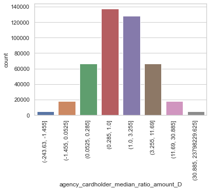

```python
import matplotlib.pyplot as plt
plt.figure(figsize=(6,4))
g = sns.countplot(x="agency_cardholder_median_ratio_amount_D", data=df4)
g.set_xticklabels(g.get_xticklabels(), rotation=90)
```

```python
df4[df4['agency_cardholder_median_ratio_amount']>2].head()
```

|  | Year_Month | Agency_Number | Agency_Name | Cardholder_Last_Name | Cardholder_First_Initial | Description | Amount | Vendor | Transaction_Date | Posted_Date | Merchant_Category | Year | Month | Week_Number | Day_of_Week | Cardholder_Name | cardholder_Median_amount | agency_cardholder_median_ratio_amount | agency_cardholder_median_ratio_amount_D |
| --- | --- | --- | --- | --- | --- | --- | --- | --- | --- | --- | --- | --- | --- | --- | --- | --- | --- | --- | --- |
| 0 | 2013-07-01 | 1000 | OKLAHOMA STATE UNIVERSITY | Mason | C | GENERAL PURCHASE | 890.00 | NACAS | 2013-07-30 | 2013-07-31 | CHARITABLE AND SOCIAL SERVICE ORGANIZATIONS | 2013 | 7 | 31 | Tuesday | Mason C | 193.80 | 4.592363 | (3.255, 11.69] |
| 2 | 2013-07-01 | 1000 | OKLAHOMA STATE UNIVERSITY | Massey | J | GENERAL PURCHASE | 165.82 | SEARS.COM 9300 | 2013-07-29 | 2013-07-31 | DIRCT MARKETING/DIRCT MARKETERS--NOT ELSEWHERE... | 2013 | 7 | 31 | Monday | Massey J | 76.50 | 2.167582 | (1.0, 3.255] |
| 4 | 2013-07-01 | 1000 | OKLAHOMA STATE UNIVERSITY | Mauro-Herrera | M | HAMMERMILL COPY PLUS COPY EA | 125.96 | STAPLES DIRECT | 2013-07-30 | 2013-07-31 | STATIONERY, OFFICE SUPPLIES, PRINTING AND WRIT... | 2013 | 7 | 31 | Tuesday | Mauro-Herrera M | 36.98 | 3.406165 | (3.255, 11.69] |
| 5 | 2013-07-01 | 1000 | OKLAHOMA STATE UNIVERSITY | Mauro-Herrera | M | GENERAL PURCHASE | 394.28 | KYOCERA DOCUMENT SOLUTION | 2013-07-29 | 2013-07-31 | OFFICE, PHOTOGRAPHIC, PHOTOCOPY, AND MICROFILM... | 2013 | 7 | 31 | Monday | Mauro-Herrera M | 36.98 | 10.661979 | (3.255, 11.69] |
| 12 | 2013-07-01 | 1000 | OKLAHOMA STATE UNIVERSITY | McLemore | A | GENERAL PURCHASE | 572.27 | GIDDINGS MACHINE CO. | 2013-07-30 | 2013-07-31 | COMMERCIAL EQUIPMENT, NOT ELSEWHERE CLASSIFIED | 2013 | 7 | 31 | Tuesday | McLemore A | 50.47 | 11.338815 | (3.255, 11.69] |

```python
# add new feature to complete dataframe
df_complete['agency_cardholder_median_ratio_amount'] = df4['agency_cardholder_median_ratio_amount']
```

##### Conclusion:

Similar to avg ratio, the median ratio can detect if any cardholder abuse the corporate card (spent more than the avg amount). The higher the ratio, the higher the likelihood of fraudulent transaction. Based on the past history on each cardholder, the industry can determine the appropriate benchmark ratio or the accepted tolerance range.

### Section 3.5 Feature 5: The ratio to cardholder merchant average amount

#### Thought process:

- cardholders may have regular purchasing pattern for specific merchant category
- Extreme high purchase amount compared to average is considered anomaly
- group by agency, merchant_category, and cardholder

```python
# create mean spending group by agency, merchant and cardholder
stat_by_agency = df.groupby(['Agency_Name', 'Merchant_Category','Cardholder_Name'])['Amount'].mean()
stat_by_agency = pd.DataFrame(stat_by_agency)
stat_by_agency.columns = ['merchant_cardholder_AVG_amount']
stat_by_agency
```

| Agency_Name | Merchant_Category | Cardholder_Name | merchant_cardholder_AVG_amount |
| --- | --- | --- | --- |
| ARDMORE HIGHER EDUCATION CENTER | BUSINESS SERVICES NOT ELSEWHERE CLASSIFIED | Ray M | 115.120000 |
|  | CATALOG MERCHANTS | Ray M | -53.344286 |
|  | COMPUTER NETWORK/INFORMATION SERVICES | Pollard C | 18.340000 |
|  | DRUG STORES AND PHARMACIES | Ray M | 153.450000 |
|  | GROCERY STORES,AND SUPERMARKETS | Ray M | 85.620000 |
| ... | ... | ... | ... |
| `DEPARTMENT OF EDUCATION | TRAVEL AGENCIES | Ross P | 24.253731 |
|  | TROPICANA RESORT AND CASINO | Ross P | 481.600000 |
|  | UNITED AIRLINES | Ross P | 310.547368 |
|  | WYNDHAM HOTELS | Bowman I | 304.980000 |
|  |  | Ross P | 58.000000 |

70246 rows × 1 columns

```python
# add the new feature cardholder median spending to the dataset
df5 = pd.merge(df, stat_by_agency, how='left', on=['Agency_Name', 'Merchant_Category','Cardholder_Name'])
# Feature 5: ratio of amount spending and average spending by cardholder and merchant
df5['agency_cardholder_merchant_avg_ratio_amount'] = np.where(df5['merchant_cardholder_AVG_amount']==0,0, df5['Amount'] / df5['merchant_cardholder_AVG_amount'])
df5['agency_cardholder_merchant_avg_ratio_amount'].describe()
```

```
count    4.424580e+05
mean     7.504713e-01
std      4.286705e+15
min     -7.901622e+17
25%      3.534415e-01
50%      8.380322e-01
75%      1.200000e+00
max      7.901622e+17
Name: agency_cardholder_merchant_avg_ratio_amount, dtype: float64
```

```python
# cut by percentile for plotting
var = 'agency_cardholder_merchant_avg_ratio_amount'
binned_var = var + '_D'
percentile = [0,0.01,0.05,0.2,0.5,0.8,0.95,0.99,1]
df5[binned_var] = pd.qcut(df5[var],percentile)
```

```
[Text(0, 0, '(-7.901621841216878e+17, -0.937]'),
```

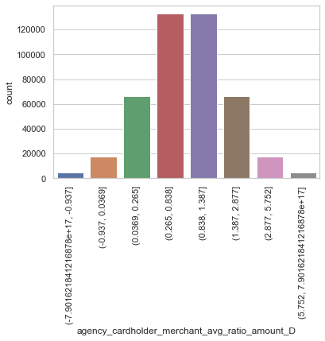

```python
import matplotlib.pyplot as plt
plt.figure(figsize=(6,4))
g = sns.countplot(x="agency_cardholder_merchant_avg_ratio_amount_D", data=df5)
g.set_xticklabels(g.get_xticklabels(), rotation=90)
```

```python
df5[df5['agency_cardholder_merchant_avg_ratio_amount']>2].head()
```

|  | Year_Month | Agency_Number | Agency_Name | Cardholder_Last_Name | Cardholder_First_Initial | Description | Amount | Vendor | Transaction_Date | Posted_Date | Merchant_Category | Year | Month | Week_Number | Day_of_Week | Cardholder_Name | merchant_cardholder_AVG_amount | agency_cardholder_merchant_avg_ratio_amount | agency_cardholder_merchant_avg_ratio_amount_D |
| --- | --- | --- | --- | --- | --- | --- | --- | --- | --- | --- | --- | --- | --- | --- | --- | --- | --- | --- | --- |
| 2 | 2013-07-01 | 1000 | OKLAHOMA STATE UNIVERSITY | Massey | J | GENERAL PURCHASE | 165.82 | SEARS.COM 9300 | 2013-07-29 | 2013-07-31 | DIRCT MARKETING/DIRCT MARKETERS--NOT ELSEWHERE... | 2013 | 7 | 31 | Monday | Massey J | 78.725000 | 2.106319 | (1.387, 2.877] |
| 14 | 2013-07-01 | 1000 | OKLAHOMA STATE UNIVERSITY | Meints | K | GENERAL PURCHASE | 445.00 | OK DEPT OF VO-TECH ED | 2013-07-30 | 2013-07-31 | GOVERNMENT SERVICES--NOT ELSEWHERE CLASSIFIED | 2013 | 7 | 31 | Tuesday | Meints K | 164.942857 | 2.697904 | (1.387, 2.877] |
| 26 | 2013-07-01 | 1000 | OKLAHOMA STATE UNIVERSITY | Foye | S | GENERAL PURCHASE | 178.00 | AFFYMETRIX, INC | 2013-07-26 | 2013-07-29 | DENTAL/LABORATORY/MEDICAL/OPHTHALMIC HOSP EQIP... | 2013 | 7 | 30 | Friday | Foye S | 74.000000 | 2.405405 | (1.387, 2.877] |
| 47 | 2013-07-01 | 1000 | OKLAHOMA STATE UNIVERSITY | DALCOUR | K | GENERAL PURCHASE | 1312.20 | NATURAL WATER COMPANY LLC | 2013-07-24 | 2013-07-26 | BUSINESS SERVICES NOT ELSEWHERE CLASSIFIED | 2013 | 7 | 30 | Wednesday | DALCOUR K | 368.033333 | 3.565438 | (2.877, 5.752] |
| 50 | 2013-07-01 | 1000 | OKLAHOMA STATE UNIVERSITY | Davis | G | Disposable GlovesNitrile EA\|Ear Plugs32dBW/o C... | 714.94 | WW GRAINGER | 2013-07-24 | 2013-07-26 | INDUSTRIAL SUPPLIES NOT ELSEWHERE CLASSIFIED | 2013 | 7 | 30 | Wednesday | Davis G | 129.053182 | 5.539887 | (2.877, 5.752] |

```python
# add new feature to complete dataframe
df_complete['agency_cardholder_merchant_avg_ratio_amount'] = df5['agency_cardholder_merchant_avg_ratio_amount']
```

##### Conclusion:

The feature reveal the average purchasing pattern for each cardholder in each merchant category. The higher the ratio to the merchant cardholder average amount, the higher the likelihood of fraudulent transaction.

### Section 3.6 Feature 6: The ratio to cardholder merchant median amount

- The only difference to the above feature (feature 5) is "median".

```python
# create mean spending group by agency, merchant and cardholder
stat_by_agency = df.groupby(['Agency_Name', 'Merchant_Category','Cardholder_Name'])['Amount'].median()
stat_by_agency = pd.DataFrame(stat_by_agency)
stat_by_agency.columns = ['merchant_cardholder_median_amount']
stat_by_agency
```

| Agency_Name | Merchant_Category | Cardholder_Name | merchant_cardholder_median_amount |
| --- | --- | --- | --- |
| ARDMORE HIGHER EDUCATION CENTER | BUSINESS SERVICES NOT ELSEWHERE CLASSIFIED | Ray M | 115.12 |
|  | CATALOG MERCHANTS | Ray M | 38.16 |
|  | COMPUTER NETWORK/INFORMATION SERVICES | Pollard C | 18.34 |
|  | DRUG STORES AND PHARMACIES | Ray M | 153.45 |
|  | GROCERY STORES,AND SUPERMARKETS | Ray M | 66.78 |
| ... | ... | ... | ... |
| `DEPARTMENT OF EDUCATION | TRAVEL AGENCIES | Ross P | 25.00 |
|  | TROPICANA RESORT AND CASINO | Ross P | 481.60 |
|  | UNITED AIRLINES | Ross P | 510.60 |
|  | WYNDHAM HOTELS | Bowman I | 304.98 |
|  |  | Ross P | 87.00 |

70246 rows × 1 columns

```python
# add the new feature cardholder median spending to the dataset
df6 = pd.merge(df, stat_by_agency, how='left', on=['Agency_Name', 'Merchant_Category','Cardholder_Name'])
# Feature 6: ratio of amount spending and median spending by cardholder and merchant
df6['agency_cardholder_merchant_median_ratio_amount'] = np.where(df6['merchant_cardholder_median_amount']==0,0, df6['Amount'] / df6['merchant_cardholder_median_amount'])
df6['agency_cardholder_merchant_median_ratio_amount'].describe()
```

```
count    4.424580e+05
mean     1.050664e+02
std      4.860020e+04
min     -8.195918e+02
25%      6.256754e-01
50%      1.000000e+00
75%      1.497567e+00
max      2.379823e+07
Name: agency_cardholder_merchant_median_ratio_amount, dtype: float64
```

```python
# cut by percentile for plotting
var = 'agency_cardholder_merchant_median_ratio_amount'
binned_var = var + '_D'
percentile = [0,0.01,0.05,0.2,0.5,0.8,0.95,0.99,1]
df6[binned_var] = pd.qcut(df6[var],percentile)
```

```
[Text(0, 0, '(-819.593, -1.077]'),
```

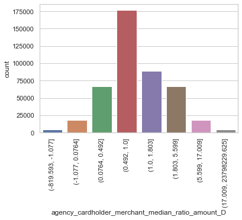

```python
import matplotlib.pyplot as plt
plt.figure(figsize=(6,4))
g = sns.countplot(x="agency_cardholder_merchant_median_ratio_amount_D", data=df6)
g.set_xticklabels(g.get_xticklabels(), rotation=90)
```

```python
df6[df6['agency_cardholder_merchant_median_ratio_amount']>2].head()
```

|  | Year_Month | Agency_Number | Agency_Name | Cardholder_Last_Name | Cardholder_First_Initial | Description | Amount | Vendor | Transaction_Date | Posted_Date | Merchant_Category | Year | Month | Week_Number | Day_of_Week | Cardholder_Name | merchant_cardholder_median_amount | agency_cardholder_merchant_median_ratio_amount | agency_cardholder_merchant_median_ratio_amount_D |
| --- | --- | --- | --- | --- | --- | --- | --- | --- | --- | --- | --- | --- | --- | --- | --- | --- | --- | --- | --- |
| 2 | 2013-07-01 | 1000 | OKLAHOMA STATE UNIVERSITY | Massey | J | GENERAL PURCHASE | 165.82 | SEARS.COM 9300 | 2013-07-29 | 2013-07-31 | DIRCT MARKETING/DIRCT MARKETERS--NOT ELSEWHERE... | 2013 | 7 | 31 | Monday | Massey J | 78.725 | 2.106319 | (1.803, 5.599] |
| 4 | 2013-07-01 | 1000 | OKLAHOMA STATE UNIVERSITY | Mauro-Herrera | M | HAMMERMILL COPY PLUS COPY EA | 125.96 | STAPLES DIRECT | 2013-07-30 | 2013-07-31 | STATIONERY, OFFICE SUPPLIES, PRINTING AND WRIT... | 2013 | 7 | 31 | Tuesday | Mauro-Herrera M | 55.060 | 2.287686 | (1.803, 5.599] |
| 11 | 2013-07-01 | 1000 | OKLAHOMA STATE UNIVERSITY | McKee | P | GENERAL PURCHASE | 127.80 | DEARINGER PRINTING & TROP | 2013-07-30 | 2013-07-31 | MISCELLANEOUS AND SPECIALTY RETAIL STORES | 2013 | 7 | 31 | Tuesday | McKee P | 28.425 | 4.496042 | (1.803, 5.599] |
| 14 | 2013-07-01 | 1000 | OKLAHOMA STATE UNIVERSITY | Meints | K | GENERAL PURCHASE | 445.00 | OK DEPT OF VO-TECH ED | 2013-07-30 | 2013-07-31 | GOVERNMENT SERVICES--NOT ELSEWHERE CLASSIFIED | 2013 | 7 | 31 | Tuesday | Meints K | 130.000 | 3.423077 | (1.803, 5.599] |
| 26 | 2013-07-01 | 1000 | OKLAHOMA STATE UNIVERSITY | Foye | S | GENERAL PURCHASE | 178.00 | AFFYMETRIX, INC | 2013-07-26 | 2013-07-29 | DENTAL/LABORATORY/MEDICAL/OPHTHALMIC HOSP EQIP... | 2013 | 7 | 30 | Friday | Foye S | 74.000 | 2.405405 | (1.803, 5.599] |

```python
# add new feature to complete dataframe
df_complete['agency_cardholder_merchant_median_ratio_amount'] = df6['agency_cardholder_merchant_median_ratio_amount']
```

##### Conclusion:

Similar to average method, the median feature also reveal the purchasing pattern for each cardholder in each merchant category and reduce the effect on extreme outliers. The higher the ratio to the merchant cardholder average amount, the higher the likelihood of fraudulent transaction.

### Section 3.7 Feature 7: The ratio to merchant average per month

#### Thought process:

- From EDA, number of transactions are different by months (some month has more transactions and others has less)
- purchasing pattern might be different per month (with high demanding month and low demanding month)
- so group by agency, merchant and month to detect high likelihood of fruadulent activities by month

```python
# create mean spending group by agency and merchant per month
stat_by_agency = df.groupby(['Agency_Name', 'Merchant_Category','Month'])['Amount'].mean()
stat_by_agency = pd.DataFrame(stat_by_agency)
stat_by_agency.columns = ['merchant_AVG_amount_per_month']
stat_by_agency
```

| Agency_Name | Merchant_Category | Month | merchant_AVG_amount_per_month |
| --- | --- | --- | --- |
| ARDMORE HIGHER EDUCATION CENTER | BUSINESS SERVICES NOT ELSEWHERE CLASSIFIED | 11 | 115.120000 |
|  | CATALOG MERCHANTS | 7 | -637.750000 |
|  |  | 8 | 669.080000 |
|  |  | 9 | -334.540000 |
|  |  | 10 | 334.540000 |
| ... | ... | ... | ... |
| `DEPARTMENT OF EDUCATION | UNITED AIRLINES | 9 | 260.450000 |
|  |  | 10 | 523.800000 |
|  |  | 12 | 199.633333 |
|  | WYNDHAM HOTELS | 1 | 0.000000 |
|  |  | 12 | 130.596000 |

39888 rows × 1 columns

```python
# add the new feature cardholder median spending to the dataset
df7 = pd.merge(df, stat_by_agency, how='left', on=['Agency_Name', 'Merchant_Category','Month'])
# Feature 7: ratio of amount spending and average spending by merchant per month
df7['agency_merchant_month_avg_ratio_amount'] = np.where(df7['merchant_AVG_amount_per_month']==0,0, df7['Amount'] / df7['merchant_AVG_amount_per_month'])
df7['agency_merchant_month_avg_ratio_amount'].describe()
```

```
count    4.424580e+05
mean     9.991488e-01
std      5.961952e+13
min     -2.447706e+16
25%      2.017647e-01
50%      5.984763e-01
75%      1.125213e+00
max      3.059633e+16
Name: agency_merchant_month_avg_ratio_amount, dtype: float64
```

```python
# cut by percentile for plotting
var = 'agency_merchant_month_avg_ratio_amount'
binned_var = var + '_D'
percentile = [0,0.01,0.05,0.2,0.5,0.8,0.95,0.99,1]
df7[binned_var] = pd.qcut(df7[var],percentile)
```

```
[Text(0, 0, '(-2.4477063974758644e+16, -0.734]'),
```

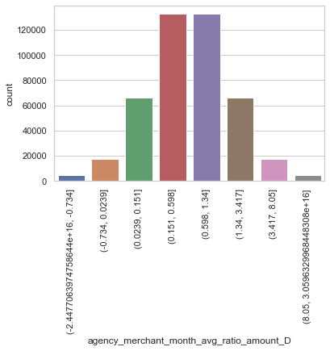

```python
import matplotlib.pyplot as plt
plt.figure(figsize=(6,4))
g = sns.countplot(x="agency_merchant_month_avg_ratio_amount_D", data=df7)
g.set_xticklabels(g.get_xticklabels(), rotation=90)
```

```python
df7[df7['agency_merchant_month_avg_ratio_amount']>2].head()
```

|  | Year_Month | Agency_Number | Agency_Name | Cardholder_Last_Name | Cardholder_First_Initial | Description | Amount | Vendor | Transaction_Date | Posted_Date | Merchant_Category | Year | Month | Week_Number | Day_of_Week | Cardholder_Name | merchant_AVG_amount_per_month | agency_merchant_month_avg_ratio_amount | agency_merchant_month_avg_ratio_amount_D |
| --- | --- | --- | --- | --- | --- | --- | --- | --- | --- | --- | --- | --- | --- | --- | --- | --- | --- | --- | --- |
| 16 | 2013-07-01 | 1000 | OKLAHOMA STATE UNIVERSITY | Mohiuddin | I | GENERAL PURCHASE | 2425.0 | WESTERN EQUIPMENT ALVA | 2013-07-29 | 2013-07-31 | HARDWARE STORES | 2013 | 7 | 31 | Monday | Mohiuddin I | 235.679053 | 10.289417 | (8.05, 3.0596329968448308e+16] |
| 17 | 2013-07-01 | 1000 | OKLAHOMA STATE UNIVERSITY | Mohiuddin | I | GENERAL PURCHASE | 2425.0 | WESTERN EQUIPMENT ALVA | 2013-07-29 | 2013-07-31 | HARDWARE STORES | 2013 | 7 | 31 | Monday | Mohiuddin I | 235.679053 | 10.289417 | (8.05, 3.0596329968448308e+16] |
| 33 | 2013-07-01 | 1000 | OKLAHOMA STATE UNIVERSITY | Gerlt | T | GENERAL PURCHASE | 3582.0 | TELVENT | 2013-07-26 | 2013-07-29 | BUSINESS SERVICES NOT ELSEWHERE CLASSIFIED | 2013 | 7 | 30 | Friday | Gerlt T | 568.982548 | 6.295448 | (3.417, 8.05] |
| 47 | 2013-07-01 | 1000 | OKLAHOMA STATE UNIVERSITY | DALCOUR | K | GENERAL PURCHASE | 1312.2 | NATURAL WATER COMPANY LLC | 2013-07-24 | 2013-07-26 | BUSINESS SERVICES NOT ELSEWHERE CLASSIFIED | 2013 | 7 | 30 | Wednesday | DALCOUR K | 568.982548 | 2.306222 | (1.34, 3.417] |
| 49 | 2013-07-01 | 1000 | OKLAHOMA STATE UNIVERSITY | DALCOUR | K | GENERAL PURCHASE | 914.0 | AUTO-CHLOR SERVICES INC | 2013-07-24 | 2013-07-26 | CATALOG MERCHANTS | 2013 | 7 | 30 | Wednesday | DALCOUR K | 450.829655 | 2.027373 | (1.34, 3.417] |

```python
# add new feature to complete dataframe
df_complete['agency_merchant_month_avg_ratio_amount'] = df7['agency_merchant_month_avg_ratio_amount']
```

##### Conclusion:

The feature reveal the monthly purchasing pattern by merchant cateogories. The higher the ratio, the higher the likelihood of fraudulent transaction in the month.

### Section 3.8 Feature 8: The ratio to merchant median per month

- The only difference to the above feature (feature 7) is "median".

```python
# create median spending group by agency and merchant per month
stat_by_agency = df.groupby(['Agency_Name', 'Merchant_Category','Month'])['Amount'].median()
stat_by_agency = pd.DataFrame(stat_by_agency)
stat_by_agency.columns = ['merchant_median_amount_per_month']
stat_by_agency
```

| Agency_Name | Merchant_Category | Month | merchant_median_amount_per_month |
| --- | --- | --- | --- |
| ARDMORE HIGHER EDUCATION CENTER | BUSINESS SERVICES NOT ELSEWHERE CLASSIFIED | 11 | 115.12 |
|  | CATALOG MERCHANTS | 7 | -637.75 |
|  |  | 8 | 669.08 |
|  |  | 9 | -334.54 |
|  |  | 10 | 334.54 |
| ... | ... | ... | ... |
| `DEPARTMENT OF EDUCATION | UNITED AIRLINES | 9 | 510.60 |
|  |  | 10 | 523.80 |
|  |  | 12 | 181.80 |
|  | WYNDHAM HOTELS | 1 | 0.00 |
|  |  | 12 | 87.00 |

39888 rows × 1 columns

```python
# add the new feature cardholder median spending to the dataset
df8 = pd.merge(df, stat_by_agency, how='left', on=['Agency_Name', 'Merchant_Category','Month'])
# Feature 8: ratio of amount spending and median spending by merchant per month
df8['agency_merchant_month_median_ratio_amount'] = np.where(df8['merchant_median_amount_per_month']==0,0, df8['Amount'] / df8['merchant_median_amount_per_month'])
df8['agency_merchant_month_median_ratio_amount'].describe()
```

```
count    442458.000000
mean          5.010047
std        1195.766096
min      -29642.000000
25%           0.500000
50%           1.000000
75%           1.912717
max      598420.505983
Name: agency_merchant_month_median_ratio_amount, dtype: float64
```

```python
# cut by percentile for plotting
var = 'agency_merchant_month_median_ratio_amount'
binned_var = var + '_D'
percentile = [0,0.01,0.05,0.2,0.5,0.8,0.95,0.99,1]
df8[binned_var] = pd.qcut(df8[var],percentile)
```

```
[Text(0, 0, '(-29642.001, -1.103]'),
```

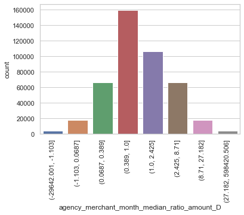

```python
import matplotlib.pyplot as plt
plt.figure(figsize=(6,4))
g = sns.countplot(x="agency_merchant_month_median_ratio_amount_D", data=df8)
g.set_xticklabels(g.get_xticklabels(), rotation=90)
```

```python
df8[df8['agency_merchant_month_median_ratio_amount']>2].head()
```

|  | Year_Month | Agency_Number | Agency_Name | Cardholder_Last_Name | Cardholder_First_Initial | Description | Amount | Vendor | Transaction_Date | Posted_Date | Merchant_Category | Year | Month | Week_Number | Day_of_Week | Cardholder_Name | merchant_median_amount_per_month | agency_merchant_month_median_ratio_amount | agency_merchant_month_median_ratio_amount_D |
| --- | --- | --- | --- | --- | --- | --- | --- | --- | --- | --- | --- | --- | --- | --- | --- | --- | --- | --- | --- |
| 0 | 2013-07-01 | 1000 | OKLAHOMA STATE UNIVERSITY | Mason | C | GENERAL PURCHASE | 890.00 | NACAS | 2013-07-30 | 2013-07-31 | CHARITABLE AND SOCIAL SERVICE ORGANIZATIONS | 2013 | 7 | 31 | Tuesday | Mason C | 365.000 | 2.438356 | (2.425, 8.71] |
| 3 | 2013-07-01 | 1000 | OKLAHOMA STATE UNIVERSITY | Massey | T | GENERAL PURCHASE | 96.39 | WAL-MART #0137 | 2013-07-30 | 2013-07-31 | GROCERY STORES,AND SUPERMARKETS | 2013 | 7 | 31 | Tuesday | Massey T | 30.605 | 3.149485 | (2.425, 8.71] |
| 5 | 2013-07-01 | 1000 | OKLAHOMA STATE UNIVERSITY | Mauro-Herrera | M | GENERAL PURCHASE | 394.28 | KYOCERA DOCUMENT SOLUTION | 2013-07-29 | 2013-07-31 | OFFICE, PHOTOGRAPHIC, PHOTOCOPY, AND MICROFILM... | 2013 | 7 | 31 | Monday | Mauro-Herrera M | 174.500 | 2.259484 | (1.0, 2.425] |
| 10 | 2013-07-01 | 1000 | OKLAHOMA STATE UNIVERSITY | McGowin | R | GENERAL PURCHASE | 278.23 | RANDY'S FOODS | 2013-07-29 | 2013-07-31 | FREEZER AND LOCKER MEAT PROVISIONERS | 2013 | 7 | 31 | Monday | McGowin R | 112.700 | 2.468767 | (2.425, 8.71] |
| 12 | 2013-07-01 | 1000 | OKLAHOMA STATE UNIVERSITY | McLemore | A | GENERAL PURCHASE | 572.27 | GIDDINGS MACHINE CO. | 2013-07-30 | 2013-07-31 | COMMERCIAL EQUIPMENT, NOT ELSEWHERE CLASSIFIED | 2013 | 7 | 31 | Tuesday | McLemore A | 205.465 | 2.785243 | (2.425, 8.71] |

```python
# add new feature to complete dataframe
df_complete['agency_merchant_month_median_ratio_amount'] = df8['agency_merchant_month_median_ratio_amount']
```

##### Conclusion:

Similar to average method, the median feature also reveal the monthly purchasing pattern by merchant cateogories. The higher the ratio, the higher the likelihood of fraudulent transaction in the month.

### Section 3.9 Feature 9: The ratio to cardholder average per month

#### Thought process:

- similar to merchant category, purchasing pattern might be different per month for each cardholder (with high demanding month and low demanding month)
- so group by agency, cardholder and month to detect high likelihood of fruadulent activities by month

```python
# create mean spending group by agency and cardholder per month
stat_by_agency = df.groupby(['Agency_Name', 'Cardholder_Name','Month'])['Amount'].mean()
stat_by_agency = pd.DataFrame(stat_by_agency)
stat_by_agency.columns = ['cardholder_AVG_amount_per_month']
stat_by_agency
```

| Agency_Name | Cardholder_Name | Month | cardholder_AVG_amount_per_month |
| --- | --- | --- | --- |
| ARDMORE HIGHER EDUCATION CENTER | Pollard C | 9 | 345.000000 |
|  |  | 10 | 18.340000 |
|  |  | 11 | 11.640000 |
|  | Ray M | 7 | -186.582000 |
|  |  | 8 | 299.972000 |
| ... | ... | ... | ... |
| `DEPARTMENT OF EDUCATION | Ross P | 8 | 205.350213 |
|  |  | 9 | 262.848757 |
|  |  | 10 | 256.403796 |
|  |  | 11 | 154.906304 |
|  |  | 12 | 78.774667 |

43638 rows × 1 columns

```python
# add the new feature cardholder median spending to the dataset
df9 = pd.merge(df, stat_by_agency, how='left', on=['Agency_Name', 'Cardholder_Name','Month'])
# Feature 9: ratio of amount spending and mean spending by cardholder per month
df9['agency_cardholder_month_AVG_ratio_amount'] = np.where(df9['cardholder_AVG_amount_per_month']==0,0, df9['Amount'] / df9['cardholder_AVG_amount_per_month'])
df9['agency_cardholder_month_AVG_ratio_amount'].describe()
```

```
count    4.424580e+05
mean     9.968807e-01
std      1.483136e+14
min     -7.151575e+16
25%      1.633914e-01
50%      5.489437e-01
75%      1.310418e+00
max      6.403556e+16
Name: agency_cardholder_month_AVG_ratio_amount, dtype: float64
```

```python
# cut by percentile for plotting
var = 'agency_cardholder_month_AVG_ratio_amount'
binned_var = var + '_D'
percentile = [0,0.01,0.05,0.2,0.5,0.8,0.95,0.99,1]
df9[binned_var] = pd.qcut(df9[var],percentile)
```

```
[Text(0, 0, '(-7.151575470775992e+16, -0.91]'),
```

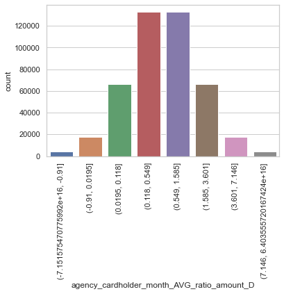

```python
import matplotlib.pyplot as plt
plt.figure(figsize=(6,4))
g = sns.countplot(x="agency_cardholder_month_AVG_ratio_amount_D", data=df9)
g.set_xticklabels(g.get_xticklabels(), rotation=90)
```

```python
df9[df9['agency_cardholder_month_AVG_ratio_amount']>2].head()
```

|  | Year_Month | Agency_Number | Agency_Name | Cardholder_Last_Name | Cardholder_First_Initial | Description | Amount | Vendor | Transaction_Date | Posted_Date | Merchant_Category | Year | Month | Week_Number | Day_of_Week | Cardholder_Name | cardholder_AVG_amount_per_month | agency_cardholder_month_AVG_ratio_amount | agency_cardholder_month_AVG_ratio_amount_D |
| --- | --- | --- | --- | --- | --- | --- | --- | --- | --- | --- | --- | --- | --- | --- | --- | --- | --- | --- | --- |
| 0 | 2013-07-01 | 1000 | OKLAHOMA STATE UNIVERSITY | Mason | C | GENERAL PURCHASE | 890.00 | NACAS | 2013-07-30 | 2013-07-31 | CHARITABLE AND SOCIAL SERVICE ORGANIZATIONS | 2013 | 7 | 31 | Tuesday | Mason C | 357.946607 | 2.486404 | (1.585, 3.601] |
| 5 | 2013-07-01 | 1000 | OKLAHOMA STATE UNIVERSITY | Mauro-Herrera | M | GENERAL PURCHASE | 394.28 | KYOCERA DOCUMENT SOLUTION | 2013-07-29 | 2013-07-31 | OFFICE, PHOTOGRAPHIC, PHOTOCOPY, AND MICROFILM... | 2013 | 7 | 31 | Monday | Mauro-Herrera M | 123.074000 | 3.203601 | (1.585, 3.601] |
| 12 | 2013-07-01 | 1000 | OKLAHOMA STATE UNIVERSITY | McLemore | A | GENERAL PURCHASE | 572.27 | GIDDINGS MACHINE CO. | 2013-07-30 | 2013-07-31 | COMMERCIAL EQUIPMENT, NOT ELSEWHERE CLASSIFIED | 2013 | 7 | 31 | Tuesday | McLemore A | 195.427143 | 2.928304 | (1.585, 3.601] |
| 15 | 2013-07-01 | 1000 | OKLAHOMA STATE UNIVERSITY | Mohiuddin | A | GENERAL PURCHASE | 452.91 | TFS THERMOASHEVILLE | 2013-07-31 | 2013-07-31 | DENTAL/LABORATORY/MEDICAL/OPHTHALMIC HOSP EQIP... | 2013 | 7 | 31 | Wednesday | Mohiuddin A | 204.432727 | 2.215448 | (1.585, 3.601] |
| 16 | 2013-07-01 | 1000 | OKLAHOMA STATE UNIVERSITY | Mohiuddin | I | GENERAL PURCHASE | 2425.00 | WESTERN EQUIPMENT ALVA | 2013-07-29 | 2013-07-31 | HARDWARE STORES | 2013 | 7 | 31 | Monday | Mohiuddin I | 404.857333 | 5.989764 | (3.601, 7.146] |

```python
# add new feature to complete dataframe
df_complete['agency_cardholder_month_AVG_ratio_amount'] = df9['agency_cardholder_month_AVG_ratio_amount']
```

##### Conclusion:

The feature reveal the monthly purchasing pattern by each cardholder. The higher the ratio, the higher the likelihood of fraudulent transaction in the month.

### Section 3.10 Feature 10: The ratio to cardholder median per month

- The only difference to the above feature (feature 9) is "median".

```python
# create median spending group by agency and cardholder per month
stat_by_agency = df.groupby(['Agency_Name', 'Cardholder_Name','Month'])['Amount'].median()
stat_by_agency = pd.DataFrame(stat_by_agency)
stat_by_agency.columns = ['cardholder_median_amount_per_month']
stat_by_agency
```

| Agency_Name | Cardholder_Name | Month | cardholder_median_amount_per_month |
| --- | --- | --- | --- |
| ARDMORE HIGHER EDUCATION CENTER | Pollard C | 9 | 345.00 |
|  |  | 10 | 18.34 |
|  |  | 11 | 11.64 |
|  | Ray M | 7 | 96.97 |
|  |  | 8 | 49.44 |
| ... | ... | ... | ... |
| `DEPARTMENT OF EDUCATION | Ross P | 8 | 86.63 |
|  |  | 9 | 77.00 |
|  |  | 10 | 115.83 |
|  |  | 11 | 77.40 |
|  |  | 12 | 87.00 |

43638 rows × 1 columns

```python
# add the new feature cardholder median spending to the dataset
df10 = pd.merge(df, stat_by_agency, how='left', on=['Agency_Name', 'Cardholder_Name','Month'])
# Feature 10: ratio of amount spending and median spending by cardholder per month
df10['agency_cardholder_month_median_ratio_amount'] = np.where(df10['cardholder_median_amount_per_month']==0,0, df10['Amount'] / df10['cardholder_median_amount_per_month'])
df10['agency_cardholder_month_median_ratio_amount'].describe()
```

```
count    442458.000000
mean          2.601100
std          85.075074
min      -49090.000000
25%           0.422071
50%           1.000000
75%           2.167045
max        6000.000000
Name: agency_cardholder_month_median_ratio_amount, dtype: float64
```

```python
# cut by percentile for plotting
var = 'agency_cardholder_month_median_ratio_amount'
binned_var = var + '_D'
percentile = [0,0.01,0.05,0.2,0.5,0.8,0.95,0.99,1]
df10[binned_var] = pd.qcut(df10[var],percentile)
```

```
[Text(0, 0, '(-49090.001, -1.454]'),
```

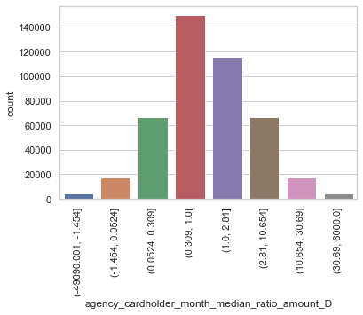

```python
import matplotlib.pyplot as plt
plt.figure(figsize=(6,4))
g = sns.countplot(x="agency_cardholder_month_median_ratio_amount_D", data=df10)
g.set_xticklabels(g.get_xticklabels(), rotation=90)
```

```python
df10[df10['agency_cardholder_month_median_ratio_amount']>2].head()
```

|  | Year_Month | Agency_Number | Agency_Name | Cardholder_Last_Name | Cardholder_First_Initial | Description | Amount | Vendor | Transaction_Date | Posted_Date | Merchant_Category | Year | Month | Week_Number | Day_of_Week | Cardholder_Name | cardholder_median_amount_per_month | agency_cardholder_month_median_ratio_amount | agency_cardholder_month_median_ratio_amount_D |
| --- | --- | --- | --- | --- | --- | --- | --- | --- | --- | --- | --- | --- | --- | --- | --- | --- | --- | --- | --- |
| 0 | 2013-07-01 | 1000 | OKLAHOMA STATE UNIVERSITY | Mason | C | GENERAL PURCHASE | 890.00 | NACAS | 2013-07-30 | 2013-07-31 | CHARITABLE AND SOCIAL SERVICE ORGANIZATIONS | 2013 | 7 | 31 | Tuesday | Mason C | 337.02 | 2.640793 | (1.0, 2.81] |
| 4 | 2013-07-01 | 1000 | OKLAHOMA STATE UNIVERSITY | Mauro-Herrera | M | HAMMERMILL COPY PLUS COPY EA | 125.96 | STAPLES DIRECT | 2013-07-30 | 2013-07-31 | STATIONERY, OFFICE SUPPLIES, PRINTING AND WRIT... | 2013 | 7 | 31 | Tuesday | Mauro-Herrera M | 38.79 | 3.247229 | (2.81, 10.654] |
| 5 | 2013-07-01 | 1000 | OKLAHOMA STATE UNIVERSITY | Mauro-Herrera | M | GENERAL PURCHASE | 394.28 | KYOCERA DOCUMENT SOLUTION | 2013-07-29 | 2013-07-31 | OFFICE, PHOTOGRAPHIC, PHOTOCOPY, AND MICROFILM... | 2013 | 7 | 31 | Monday | Mauro-Herrera M | 38.79 | 10.164475 | (2.81, 10.654] |
| 12 | 2013-07-01 | 1000 | OKLAHOMA STATE UNIVERSITY | McLemore | A | GENERAL PURCHASE | 572.27 | GIDDINGS MACHINE CO. | 2013-07-30 | 2013-07-31 | COMMERCIAL EQUIPMENT, NOT ELSEWHERE CLASSIFIED | 2013 | 7 | 31 | Tuesday | McLemore A | 83.94 | 6.817608 | (2.81, 10.654] |
| 15 | 2013-07-01 | 1000 | OKLAHOMA STATE UNIVERSITY | Mohiuddin | A | GENERAL PURCHASE | 452.91 | TFS THERMOASHEVILLE | 2013-07-31 | 2013-07-31 | DENTAL/LABORATORY/MEDICAL/OPHTHALMIC HOSP EQIP... | 2013 | 7 | 31 | Wednesday | Mohiuddin A | 91.36 | 4.957421 | (2.81, 10.654] |

```python
# add new feature to complete dataframe
df_complete['agency_cardholder_month_median_ratio_amount'] = df10['agency_cardholder_month_median_ratio_amount']
```

##### Conclusion:

Similar to average method, the median feature also reveals the monthly purchasing pattern by each cardholder. The higher the ratio, the higher the likelihood of fraudulent transaction in the month.

### Section 3.11 Feature 11: The ratio to merchant average on the same day

#### Thought process:

- High number of transactions and high transaction amount in one day is highly likely to be fradulent activities
- so group by agency, merchant and transaction date

```python
# create mean spending group by agency and merchant on transaction days
stat_by_agency = df.groupby(['Agency_Name', 'Merchant_Category','Transaction_Date'])['Amount'].mean()
stat_by_agency = pd.DataFrame(stat_by_agency)
stat_by_agency.columns = ['merchant_AVG_amount_sameday']
stat_by_agency
```

| Agency_Name | Merchant_Category | Transaction_Date | merchant_AVG_amount_sameday |
| --- | --- | --- | --- |
| ARDMORE HIGHER EDUCATION CENTER | BUSINESS SERVICES NOT ELSEWHERE CLASSIFIED | 2013-11-08 | 115.12 |
|  | CATALOG MERCHANTS | 2013-07-12 | -606.42 |
|  |  | 2013-07-25 | -669.08 |
|  |  | 2013-08-02 | 669.08 |
|  |  | 2013-09-05 | -334.54 |
| ... | ... | ... | ... |
| `DEPARTMENT OF EDUCATION | UNITED AIRLINES | 2013-12-19 | 197.80 |
|  |  | 2013-12-26 | 272.80 |
|  | WYNDHAM HOTELS | 2013-12-05 | 87.00 |
|  |  | 2013-12-17 | 304.98 |
|  |  | 2013-12-31 | 0.00 |

164355 rows × 1 columns

```python
# add the new feature cardholder median spending to the dataset
df11 = pd.merge(df, stat_by_agency, how='left', on=['Agency_Name', 'Merchant_Category','Transaction_Date'])
# Feature 11: ratio of amount spending and mean spending by merchant on the same day
df11['agency_merchant_sameday_AVG_ratio_amount'] = np.where(df11['merchant_AVG_amount_sameday']==0,0, df11['Amount'] / df11['merchant_AVG_amount_sameday'])
df11['agency_merchant_sameday_AVG_ratio_amount'].describe()
```

```
count    4.424580e+05
mean     9.908116e-01
std      3.099853e+15
min     -5.875565e+17
25%      3.984064e-01
50%      1.000000e+00
75%      1.086957e+00
max      5.875565e+17
Name: agency_merchant_sameday_AVG_ratio_amount, dtype: float64
```

```python
# cut by percentile for plotting
var = 'agency_merchant_sameday_AVG_ratio_amount'
binned_var = var + '_D'
percentile = [0,0.01,0.05,0.2,0.5,0.8,0.95,0.99,1]
df11[binned_var] = pd.qcut(df11[var],percentile)
```

```
[Text(0, 0, '(-5.875564958853576e+17, -0.838]'),
```

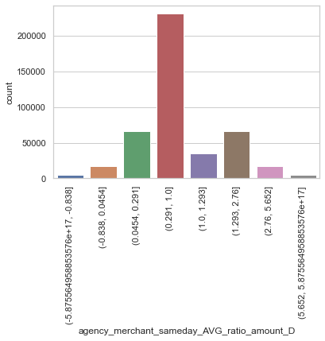

```python
import matplotlib.pyplot as plt
plt.figure(figsize=(6,4))
g = sns.countplot(x="agency_merchant_sameday_AVG_ratio_amount_D", data=df11)
g.set_xticklabels(g.get_xticklabels(), rotation=90)
```

```python
df11[df11['agency_merchant_sameday_AVG_ratio_amount']>2].head()
```

|  | Year_Month | Agency_Number | Agency_Name | Cardholder_Last_Name | Cardholder_First_Initial | Description | Amount | Vendor | Transaction_Date | Posted_Date | Merchant_Category | Year | Month | Week_Number | Day_of_Week | Cardholder_Name | merchant_AVG_amount_sameday | agency_merchant_sameday_AVG_ratio_amount | agency_merchant_sameday_AVG_ratio_amount_D |
| --- | --- | --- | --- | --- | --- | --- | --- | --- | --- | --- | --- | --- | --- | --- | --- | --- | --- | --- | --- |
| 3 | 2013-07-01 | 1000 | OKLAHOMA STATE UNIVERSITY | Massey | T | GENERAL PURCHASE | 96.39 | WAL-MART #0137 | 2013-07-30 | 2013-07-31 | GROCERY STORES,AND SUPERMARKETS | 2013 | 7 | 31 | Tuesday | Massey T | 46.278824 | 2.082810 | (1.293, 2.76] |
| 16 | 2013-07-01 | 1000 | OKLAHOMA STATE UNIVERSITY | Mohiuddin | I | GENERAL PURCHASE | 2425.00 | WESTERN EQUIPMENT ALVA | 2013-07-29 | 2013-07-31 | HARDWARE STORES | 2013 | 7 | 31 | Monday | Mohiuddin I | 272.520556 | 8.898411 | (5.652, 5.875564958853576e+17] |
| 17 | 2013-07-01 | 1000 | OKLAHOMA STATE UNIVERSITY | Mohiuddin | I | GENERAL PURCHASE | 2425.00 | WESTERN EQUIPMENT ALVA | 2013-07-29 | 2013-07-31 | HARDWARE STORES | 2013 | 7 | 31 | Monday | Mohiuddin I | 272.520556 | 8.898411 | (5.652, 5.875564958853576e+17] |
| 33 | 2013-07-01 | 1000 | OKLAHOMA STATE UNIVERSITY | Gerlt | T | GENERAL PURCHASE | 3582.00 | TELVENT | 2013-07-26 | 2013-07-29 | BUSINESS SERVICES NOT ELSEWHERE CLASSIFIED | 2013 | 7 | 30 | Friday | Gerlt T | 1234.718667 | 2.901066 | (2.76, 5.652] |
| 50 | 2013-07-01 | 1000 | OKLAHOMA STATE UNIVERSITY | Davis | G | Disposable GlovesNitrile EA\|Ear Plugs32dBW/o C... | 714.94 | WW GRAINGER | 2013-07-24 | 2013-07-26 | INDUSTRIAL SUPPLIES NOT ELSEWHERE CLASSIFIED | 2013 | 7 | 30 | Wednesday | Davis G | 266.519600 | 2.682504 | (1.293, 2.76] |

```python
# add new feature to complete dataframe
df_complete['agency_merchant_sameday_AVG_ratio_amount'] = df11['agency_merchant_sameday_AVG_ratio_amount']
```

##### Conclusion:

The higher the ratio, the higher the likelihood of fraudulent transaction.

### Section 3.12 Feature 12: The ratio to merchant median on the same day

- The only difference to the above feature (feature 11) is "median".

```python
# create median spending group by agency and merchant on transaction days
stat_by_agency = df.groupby(['Agency_Name', 'Merchant_Category','Transaction_Date'])['Amount'].median()
stat_by_agency = pd.DataFrame(stat_by_agency)
stat_by_agency.columns = ['merchant_median_amount_sameday']
stat_by_agency
```

| Agency_Name | Merchant_Category | Transaction_Date | merchant_median_amount_sameday |
| --- | --- | --- | --- |
| ARDMORE HIGHER EDUCATION CENTER | BUSINESS SERVICES NOT ELSEWHERE CLASSIFIED | 2013-11-08 | 115.12 |
|  | CATALOG MERCHANTS | 2013-07-12 | -606.42 |
|  |  | 2013-07-25 | -669.08 |
|  |  | 2013-08-02 | 669.08 |
|  |  | 2013-09-05 | -334.54 |
| ... | ... | ... | ... |
| `DEPARTMENT OF EDUCATION | UNITED AIRLINES | 2013-12-19 | 197.80 |
|  |  | 2013-12-26 | 272.80 |
|  | WYNDHAM HOTELS | 2013-12-05 | 87.00 |
|  |  | 2013-12-17 | 304.98 |
|  |  | 2013-12-31 | 0.00 |

164355 rows × 1 columns

```python
# add the new feature cardholder median spending to the dataset
df12 = pd.merge(df, stat_by_agency, how='left', on=['Agency_Name', 'Merchant_Category','Transaction_Date'])
# Feature 12: ratio of amount spending and median spending by merchant on the same day
df12['agency_merchant_sameday_median_ratio_amount'] = np.where(df12['merchant_median_amount_sameday']==0,0, df12['Amount'] / df12['merchant_median_amount_sameday'])
df12['agency_merchant_sameday_median_ratio_amount'].describe()
```

```
count    442458.000000
mean          2.558953
std         472.959016
min       -6336.000000
25%           0.750000
50%           1.000000
75%           1.286993
max      314251.342908
Name: agency_merchant_sameday_median_ratio_amount, dtype: float64
```

```python
# cut by percentile for plotting
var = 'agency_merchant_sameday_median_ratio_amount'
binned_var = var + '_D'
percentile = [0,0.01,0.05,0.2,0.5,0.8,0.95,0.99,1]
df12[binned_var] = pd.qcut(df12[var],percentile)
```

```
[Text(0, 0, '(-6336.001, -1.0]'),
```

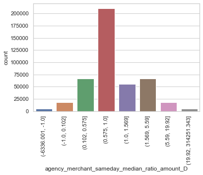

```python
import matplotlib.pyplot as plt
plt.figure(figsize=(6,4))
g = sns.countplot(x="agency_merchant_sameday_median_ratio_amount_D", data=df12)
g.set_xticklabels(g.get_xticklabels(), rotation=90)
```

```python
df12[df12['agency_merchant_sameday_median_ratio_amount']>2].head()
```

|  | Year_Month | Agency_Number | Agency_Name | Cardholder_Last_Name | Cardholder_First_Initial | Description | Amount | Vendor | Transaction_Date | Posted_Date | Merchant_Category | Year | Month | Week_Number | Day_of_Week | Cardholder_Name | merchant_median_amount_sameday | agency_merchant_sameday_median_ratio_amount | agency_merchant_sameday_median_ratio_amount_D |
| --- | --- | --- | --- | --- | --- | --- | --- | --- | --- | --- | --- | --- | --- | --- | --- | --- | --- | --- | --- |
| 3 | 2013-07-01 | 1000 | OKLAHOMA STATE UNIVERSITY | Massey | T | GENERAL PURCHASE | 96.39 | WAL-MART #0137 | 2013-07-30 | 2013-07-31 | GROCERY STORES,AND SUPERMARKETS | 2013 | 7 | 31 | Tuesday | Massey T | 43.970 | 2.192176 | (1.569, 5.59] |
| 11 | 2013-07-01 | 1000 | OKLAHOMA STATE UNIVERSITY | McKee | P | GENERAL PURCHASE | 127.80 | DEARINGER PRINTING & TROP | 2013-07-30 | 2013-07-31 | MISCELLANEOUS AND SPECIALTY RETAIL STORES | 2013 | 7 | 31 | Tuesday | McKee P | 52.390 | 2.439397 | (1.569, 5.59] |
| 12 | 2013-07-01 | 1000 | OKLAHOMA STATE UNIVERSITY | McLemore | A | GENERAL PURCHASE | 572.27 | GIDDINGS MACHINE CO. | 2013-07-30 | 2013-07-31 | COMMERCIAL EQUIPMENT, NOT ELSEWHERE CLASSIFIED | 2013 | 7 | 31 | Tuesday | McLemore A | 208.815 | 2.740560 | (1.569, 5.59] |
| 15 | 2013-07-01 | 1000 | OKLAHOMA STATE UNIVERSITY | Mohiuddin | A | GENERAL PURCHASE | 452.91 | TFS THERMOASHEVILLE | 2013-07-31 | 2013-07-31 | DENTAL/LABORATORY/MEDICAL/OPHTHALMIC HOSP EQIP... | 2013 | 7 | 31 | Wednesday | Mohiuddin A | 79.100 | 5.725790 | (5.59, 19.92] |
| 16 | 2013-07-01 | 1000 | OKLAHOMA STATE UNIVERSITY | Mohiuddin | I | GENERAL PURCHASE | 2425.00 | WESTERN EQUIPMENT ALVA | 2013-07-29 | 2013-07-31 | HARDWARE STORES | 2013 | 7 | 31 | Monday | Mohiuddin I | 55.830 | 43.435429 | (19.92, 314251.343] |

```python
# add new feature to complete dataframe
df_complete['agency_merchant_sameday_median_ratio_amount'] = df12['agency_merchant_sameday_median_ratio_amount']
```

##### Conclusion:

The higher the ratio, the higher the likelihood of fraudulent transaction.

### Section 3.13 Feature 13: The ratio to cardholder average on the same day

#### Thought process:

- one large amount spending transaction is highly likely to be denied
- group by agency, cardholder and transaction date

```python
# create mean spending group by agency and cardholder on transaction days
stat_by_agency = df.groupby(['Agency_Name', 'Cardholder_Name','Transaction_Date'])['Amount'].mean()
stat_by_agency = pd.DataFrame(stat_by_agency)
stat_by_agency.columns = ['cardholder_AVG_amount_sameday']
stat_by_agency
```

| Agency_Name | Cardholder_Name | Transaction_Date | cardholder_AVG_amount_sameday |
| --- | --- | --- | --- |
| ARDMORE HIGHER EDUCATION CENTER | Pollard C | 2013-09-10 | 345.00 |
|  |  | 2013-10-08 | 18.34 |
|  |  | 2013-10-30 | 11.64 |
|  | Ray M | 2013-06-27 | 101.63 |
|  |  | 2013-07-10 | 96.97 |
| ... | ... | ... | ... |
| `DEPARTMENT OF EDUCATION | Ross P | 2014-01-22 | 290.50 |
|  |  | 2014-01-23 | 112.35 |
|  |  | 2014-01-24 | 188.76 |
|  |  | 2014-01-27 | -77.40 |
|  |  | 2014-01-28 | 290.50 |

229382 rows × 1 columns

```python
# add the new feature cardholder median spending to the dataset
df13 = pd.merge(df, stat_by_agency, how='left', on=['Agency_Name', 'Cardholder_Name','Transaction_Date'])
# Feature 13: ratio of amount spending and mean spending by cardholder on the same day
df13['agency_cardholder_sameday_AVG_ratio_amount'] = np.where(df13['cardholder_AVG_amount_sameday']==0,0, df13['Amount'] / df13['cardholder_AVG_amount_sameday'])
df13['agency_cardholder_sameday_AVG_ratio_amount'].describe()
```

```
count    4.424580e+05
mean     9.399250e-01
std      3.345668e+15
min     -5.875565e+17
25%      5.388785e-01
50%      1.000000e+00
75%      1.105314e+00
max      5.875565e+17
Name: agency_cardholder_sameday_AVG_ratio_amount, dtype: float64
```

```python
# cut by percentile for plotting
var = 'agency_cardholder_sameday_AVG_ratio_amount'
binned_var = var + '_D'
percentile = [0,0.01,0.05,0.2,0.5,0.8,0.95,0.99,1]
df13[binned_var] = pd.qcut(df13[var],percentile)
```

```
[Text(0, 0, '(-5.875564958853576e+17, -0.724]'),
```

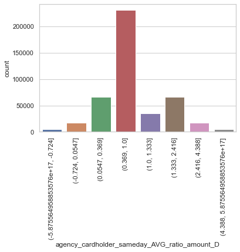

```python
import matplotlib.pyplot as plt
plt.figure(figsize=(6,4))
g = sns.countplot(x="agency_cardholder_sameday_AVG_ratio_amount_D", data=df13)
g.set_xticklabels(g.get_xticklabels(), rotation=90)
```

```python
df13[df13['agency_cardholder_sameday_AVG_ratio_amount']>2].head()
```

|  | Year_Month | Agency_Number | Agency_Name | Cardholder_Last_Name | Cardholder_First_Initial | Description | Amount | Vendor | Transaction_Date | Posted_Date | Merchant_Category | Year | Month | Week_Number | Day_of_Week | Cardholder_Name | cardholder_AVG_amount_sameday | agency_cardholder_sameday_AVG_ratio_amount | agency_cardholder_sameday_AVG_ratio_amount_D |
| --- | --- | --- | --- | --- | --- | --- | --- | --- | --- | --- | --- | --- | --- | --- | --- | --- | --- | --- | --- |
| 12 | 2013-07-01 | 1000 | OKLAHOMA STATE UNIVERSITY | McLemore | A | GENERAL PURCHASE | 572.27 | GIDDINGS MACHINE CO. | 2013-07-30 | 2013-07-31 | COMMERCIAL EQUIPMENT, NOT ELSEWHERE CLASSIFIED | 2013 | 7 | 31 | Tuesday | McLemore A | 261.413333 | 2.189139 | (1.333, 2.416] |
| 26 | 2013-07-01 | 1000 | OKLAHOMA STATE UNIVERSITY | Foye | S | GENERAL PURCHASE | 178.00 | AFFYMETRIX, INC | 2013-07-26 | 2013-07-29 | DENTAL/LABORATORY/MEDICAL/OPHTHALMIC HOSP EQIP... | 2013 | 7 | 30 | Friday | Foye S | 74.000000 | 2.405405 | (1.333, 2.416] |
| 47 | 2013-07-01 | 1000 | OKLAHOMA STATE UNIVERSITY | DALCOUR | K | GENERAL PURCHASE | 1312.20 | NATURAL WATER COMPANY LLC | 2013-07-24 | 2013-07-26 | BUSINESS SERVICES NOT ELSEWHERE CLASSIFIED | 2013 | 7 | 30 | Wednesday | DALCOUR K | 614.317500 | 2.136029 | (1.333, 2.416] |
| 54 | 2013-07-01 | 1000 | OKLAHOMA STATE UNIVERSITY | Davis | M | GENERAL PURCHASE | 159.97 | GARMIN INTERNATIONAL | 2013-07-24 | 2013-07-26 | DIRCT MARKETING/DIRCT MARKETERS--NOT ELSEWHERE... | 2013 | 7 | 30 | Wednesday | Davis M | 72.687500 | 2.200791 | (1.333, 2.416] |
| 62 | 2013-07-01 | 1000 | OKLAHOMA STATE UNIVERSITY | Dollins | D | CYLAIRBREATHING300CGA346 MO\|CYLHYDROGENUHPGR5S... | 58.66 | AIRGAS CENTRAL | 2013-07-25 | 2013-07-26 | CHEMICALS AND ALLIED PRODUCTS NOT ELSEWHERE CL... | 2013 | 7 | 30 | Thursday | Dollins D | 19.274000 | 3.043478 | (2.416, 4.388] |

```python
# add new feature to complete dataframe
df_complete['agency_cardholder_sameday_AVG_ratio_amount'] = df13['agency_cardholder_sameday_AVG_ratio_amount']
```

##### Conclusion:

The higher the ratio, the higher the likelihood of fraudulent transaction.

### Section 3.14 Feature 14: The ratio to cardholder median on the same day

- The only difference to the above feature (feature 13) is "median".

```python
# create median spending group by agency and cardholder on transaction days
stat_by_agency = df.groupby(['Agency_Name', 'Cardholder_Name','Transaction_Date'])['Amount'].median()
stat_by_agency = pd.DataFrame(stat_by_agency)
stat_by_agency.columns = ['cardholder_median_amount_sameday']
stat_by_agency
```

| Agency_Name | Cardholder_Name | Transaction_Date | cardholder_median_amount_sameday |
| --- | --- | --- | --- |
| ARDMORE HIGHER EDUCATION CENTER | Pollard C | 2013-09-10 | 345.00 |
|  |  | 2013-10-08 | 18.34 |
|  |  | 2013-10-30 | 11.64 |
|  | Ray M | 2013-06-27 | 101.63 |
|  |  | 2013-07-10 | 96.97 |
| ... | ... | ... | ... |
| `DEPARTMENT OF EDUCATION | Ross P | 2014-01-22 | 290.50 |
|  |  | 2014-01-23 | 112.35 |
|  |  | 2014-01-24 | 188.76 |
|  |  | 2014-01-27 | -77.40 |
|  |  | 2014-01-28 | 290.50 |

229382 rows × 1 columns

```python
# add the new feature cardholder median spending to the dataset
df14 = pd.merge(df, stat_by_agency, how='left', on=['Agency_Name', 'Cardholder_Name','Transaction_Date'])
# Feature 14: ratio of amount spending and median spending by cardholder on the same day
df14['agency_cardholder_sameday_median_ratio_amount'] = np.where(df14['cardholder_median_amount_sameday']==0,0, df14['Amount'] / df14['cardholder_median_amount_sameday'])
df14['agency_cardholder_sameday_median_ratio_amount'].describe()
```

```
count    442458.000000
mean          2.041701
std         174.680384
min      -44390.000000
25%           0.879397
50%           1.000000
75%           1.138714
max       63226.000000
Name: agency_cardholder_sameday_median_ratio_amount, dtype: float64
```

```python
# cut by percentile for plotting
var = 'agency_cardholder_sameday_median_ratio_amount'
binned_var = var + '_D'
percentile = [0,0.01,0.05,0.2,0.5,0.8,0.95,0.99,1]
df14[binned_var] = pd.qcut(df14[var],percentile)
```

```
[Text(0, 0, '(-44390.001, -1.0]'),
```

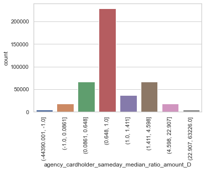

```python
import matplotlib.pyplot as plt
plt.figure(figsize=(6,4))
g = sns.countplot(x="agency_cardholder_sameday_median_ratio_amount_D", data=df14)
g.set_xticklabels(g.get_xticklabels(), rotation=90)
```

```python
df14[df14['agency_cardholder_sameday_median_ratio_amount']>2].head()
```

|  | Year_Month | Agency_Number | Agency_Name | Cardholder_Last_Name | Cardholder_First_Initial | Description | Amount | Vendor | Transaction_Date | Posted_Date | Merchant_Category | Year | Month | Week_Number | Day_of_Week | Cardholder_Name | cardholder_median_amount_sameday | agency_cardholder_sameday_median_ratio_amount | agency_cardholder_sameday_median_ratio_amount_D |
| --- | --- | --- | --- | --- | --- | --- | --- | --- | --- | --- | --- | --- | --- | --- | --- | --- | --- | --- | --- |
| 12 | 2013-07-01 | 1000 | OKLAHOMA STATE UNIVERSITY | McLemore | A | GENERAL PURCHASE | 572.27 | GIDDINGS MACHINE CO. | 2013-07-30 | 2013-07-31 | COMMERCIAL EQUIPMENT, NOT ELSEWHERE CLASSIFIED | 2013 | 7 | 31 | Tuesday | McLemore A | 169.990 | 3.366492 | (1.411, 4.598] |
| 26 | 2013-07-01 | 1000 | OKLAHOMA STATE UNIVERSITY | Foye | S | GENERAL PURCHASE | 178.00 | AFFYMETRIX, INC | 2013-07-26 | 2013-07-29 | DENTAL/LABORATORY/MEDICAL/OPHTHALMIC HOSP EQIP... | 2013 | 7 | 30 | Friday | Foye S | 74.000 | 2.405405 | (1.411, 4.598] |
| 47 | 2013-07-01 | 1000 | OKLAHOMA STATE UNIVERSITY | DALCOUR | K | GENERAL PURCHASE | 1312.20 | NATURAL WATER COMPANY LLC | 2013-07-24 | 2013-07-26 | BUSINESS SERVICES NOT ELSEWHERE CLASSIFIED | 2013 | 7 | 30 | Wednesday | DALCOUR K | 516.360 | 2.541250 | (1.411, 4.598] |
| 54 | 2013-07-01 | 1000 | OKLAHOMA STATE UNIVERSITY | Davis | M | GENERAL PURCHASE | 159.97 | GARMIN INTERNATIONAL | 2013-07-24 | 2013-07-26 | DIRCT MARKETING/DIRCT MARKETERS--NOT ELSEWHERE... | 2013 | 7 | 30 | Wednesday | Davis M | 61.535 | 2.599659 | (1.411, 4.598] |
| 62 | 2013-07-01 | 1000 | OKLAHOMA STATE UNIVERSITY | Dollins | D | CYLAIRBREATHING300CGA346 MO\|CYLHYDROGENUHPGR5S... | 58.66 | AIRGAS CENTRAL | 2013-07-25 | 2013-07-26 | CHEMICALS AND ALLIED PRODUCTS NOT ELSEWHERE CL... | 2013 | 7 | 30 | Thursday | Dollins D | 4.190 | 14.000000 | (4.598, 22.907] |

```python
# add new feature to complete dataframe
df_complete['agency_cardholder_sameday_median_ratio_amount'] = df14['agency_cardholder_sameday_median_ratio_amount']
```

##### Conclusion:

The higher the ratio, the higher the likelihood of fraudulent transaction.

## Section 4. Modeling

#### Thought process:

- unsupervised modeling to find out anomalies (high likelihood of fraudulent transaction)
- KNNs technique
- split train and test data by 80/20
- use the 14 created features
- standardize train and test data

#### What is KNNs?

- K-nearest neighbors is an unsupervised machine learning technique. It computes the Euclidean distrance of an observation to other obsevations and returns the distance of one data point to the neighboring data points.
- The k-NN distance can be used in anomaly detection. The larger the distance to the k-NN, the lower the local density, and the more likely the data point is an outlier.
- Once determine a reasonable boundary of K-NN distance (outlier score), can group the data into normal and abnormal cluster to find out the anomalies.

```python
# aggregate 14 created features
features = df_complete.iloc[:,15:29]
features.head()
```

|  | agency_merchant_avg_ratio_amount | agency_merchant_median_ratio_amount | agency_cardholder_avg_ratio_amount | agency_cardholder_median_ratio_amount | agency_cardholder_merchant_avg_ratio_amount | agency_cardholder_merchant_median_ratio_amount | agency_merchant_month_avg_ratio_amount | agency_merchant_month_median_ratio_amount | agency_cardholder_month_AVG_ratio_amount | agency_cardholder_month_median_ratio_amount | agency_merchant_sameday_AVG_ratio_amount | agency_merchant_sameday_median_ratio_amount | agency_cardholder_sameday_AVG_ratio_amount | agency_cardholder_sameday_median_ratio_amount |
| --- | --- | --- | --- | --- | --- | --- | --- | --- | --- | --- | --- | --- | --- | --- |
| 0 | 2.081219 | 3.560000 | 3.603475 | 4.592363 | 1.000000 | 1.000000 | 1.840868 | 2.438356 | 2.486404 | 2.640793 | 1.682221 | 1.561404 | 1.439570 | 1.413865 |
| 1 | 0.974461 | 1.407761 | 1.493863 | 1.903818 | 1.435311 | 1.138765 | 1.015535 | 0.853600 | 1.030768 | 1.094772 | 1.064881 | 1.064881 | 0.596791 | 0.586135 |
| 2 | 0.422515 | 0.966824 | 0.413875 | 2.167582 | 2.106319 | 2.106319 | 0.422770 | 0.874301 | 0.338562 | 1.000000 | 1.029803 | 1.286324 | 1.000000 | 1.000000 |
| 3 | 1.611007 | 2.967216 | 0.264546 | 0.463815 | 1.898048 | 1.935931 | 1.784624 | 3.149485 | 0.174541 | 1.000000 | 2.082810 | 2.192176 | 0.095076 | 0.095076 |
| 4 | 0.464432 | 1.143895 | 1.342599 | 3.406165 | 1.938502 | 2.287686 | 0.488447 | 1.172266 | 1.023449 | 3.247229 | 0.230188 | 0.514627 | 1.000000 | 1.000000 |

```python
# split train and test by 80/20
from sklearn.model_selection import train_test_split
X_train, X_test = train_test_split(features, test_size = 0.2, random_state = 0)
```

```python
# Standardize train and test
from pyod.utils.utility import standardizer
X_train_norm, X_test_norm = standardizer(X_train, X_test)
```

#### Modeling process

- aggreagte 5 knn models to achieve model stability and reduce overfitting risk
- use average method

```python
from pyod.models.knn import KNN
from pyod.models.combination import aom, moa, average, maximization

# Test a range of k-neighbors from 10 to 50. There will be 5 k-NN models.
n_clf = 5
k_list = [10, 20, 30, 40, 50]
# Just prepare data frames so we can store the model results
train_scores = np.zeros([X_train.shape[0], n_clf])
test_scores = np.zeros([X_test.shape[0], n_clf])
train_scores.shape
# Modeling
for i in range(n_clf):
    k = k_list[i]
    clf = KNN(n_neighbors=k, method='largest')
    clf.fit(X_train_norm)

    # Store the results in each column:
    train_scores[:, i] = clf.decision_scores_
    test_scores[:, i] = clf.decision_function(X_test_norm)
# Decision scores have to be normalized before combination
train_scores_norm, test_scores_norm = standardizer(train_scores,test_scores)
```

```python
# average train and test abnormal scores
y_by_average_train = average(train_scores_norm)
y_by_average_test = average(test_scores_norm)
```

#### Thought process:

- Determine a reasonable boundary from train data outlier score by plotting the histgram
- tried to use auto bins to plot the graph but did not work (running forever but not show results)
- explore the train_scores_norm statistics and then determine the bin width to be 1.
- use log scale to clearly show the histgram

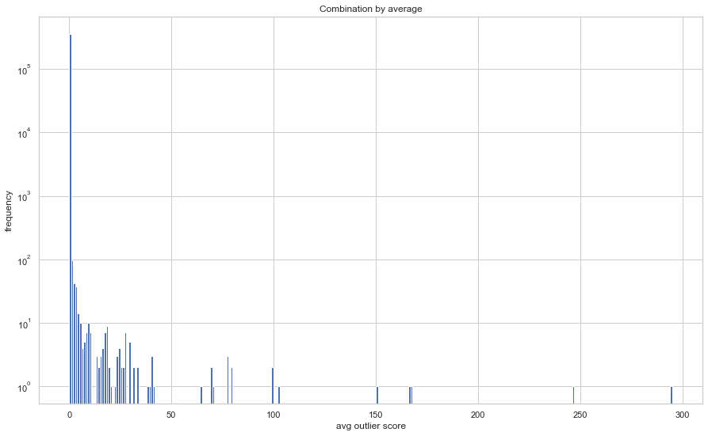

```python
import matplotlib.pyplot as plt
plt.figure(figsize = (15,9))
plt.hist(y_by_average_train,bins=np.arange(min(y_by_average_train), max(y_by_average_train) + 1, 1))
plt.title("Combination by average")
plt.yscale('log')
plt.xlabel('avg outlier score')
plt.ylabel('frequency')
plt.show()
```

cluster groups (normal vs abnormal) by the boundary of outlier score of 1.

```python
df_test = pd.DataFrame(X_test)
df_test['y_by_average_score'] = y_by_average_test
df_test['y_by_average_cluster'] = np.where(df_test['y_by_average_score']<1, 0, 1)
df_test['y_by_average_cluster'].value_counts()
```

```
0    88423
1       69
Name: y_by_average_cluster, dtype: int64
```

The model identifies 69 data points that have the outlier scores higher than 1

Below is the summary statistics of the two clusters with each feature score

```python
df_test.groupby('y_by_average_cluster').mean()
```

| y_by_average_cluster | agency_merchant_avg_ratio_amount | agency_merchant_median_ratio_amount | agency_cardholder_avg_ratio_amount | agency_cardholder_median_ratio_amount | agency_cardholder_merchant_avg_ratio_amount | agency_cardholder_merchant_median_ratio_amount | agency_merchant_month_avg_ratio_amount | agency_merchant_month_median_ratio_amount | agency_cardholder_month_AVG_ratio_amount | agency_cardholder_month_median_ratio_amount | agency_merchant_sameday_AVG_ratio_amount | agency_merchant_sameday_median_ratio_amount | agency_cardholder_sameday_AVG_ratio_amount | agency_cardholder_sameday_median_ratio_amount | y_by_average_score |
| --- | --- | --- | --- | --- | --- | --- | --- | --- | --- | --- | --- | --- | --- | --- | --- |
| 0 | 0.981379 | 2.536438 | 0.990077 | 2.848936 | 9.865026e-01 | 1.750913 | 1.000784e+00 | 2.382847 | 9.238835e-01 | 2.64874 | 9.901383e-01 | 1.832144 | -1.115719e+11 | 1.742660 | -0.012188 |
| 1 | 11.457853 | 54.916316 | 7.682215 | 50.296048 | 1.564291e+16 | 29.046361 | 4.434251e+14 | 48.106373 | -6.991734e+14 | 207.47863 | 1.233436e+16 | 20.778964 | 1.840673e+16 | -213.850606 | 17.312034 |

#### Thought process:

- After identifying the outliers, the next step is to explore the abnormal transactions.

```python
# create a new dataframe for abnromal data cluster
outliers = df_test[df_test['y_by_average_cluster'] == 1]
outl_df = pd.merge(df, outliers, left_index = True, right_index = True)
outl_df.head()
```

|  | Year_Month | Agency_Number | Agency_Name | Cardholder_Last_Name | Cardholder_First_Initial | Description | Amount | Vendor | Transaction_Date | Posted_Date | ... | agency_merchant_month_avg_ratio_amount | agency_merchant_month_median_ratio_amount | agency_cardholder_month_AVG_ratio_amount | agency_cardholder_month_median_ratio_amount | agency_merchant_sameday_AVG_ratio_amount | agency_merchant_sameday_median_ratio_amount | agency_cardholder_sameday_AVG_ratio_amount | agency_cardholder_sameday_median_ratio_amount | y_by_average_score | y_by_average_cluster |
| --- | --- | --- | --- | --- | --- | --- | --- | --- | --- | --- | --- | --- | --- | --- | --- | --- | --- | --- | --- | --- | --- |
| 18338 | 2013-08-01 | 1000 | OKLAHOMA STATE UNIVERSITY | Dady | L | GENERAL PURCHASE | 2393.88 | TARGET.COM | 2013-08-22 | 2013-08-22 | ... | 35.938748 | 49.095160 | 1.579259e+16 | -12.346588 | 2.961721 | 126.392819 | 1.000000e+00 | 1.0 | 41.441736 | 1 |
| 19147 | 2013-08-01 | 1000 | OKLAHOMA STATE UNIVERSITY | Ray | M | GENERAL PURCHASE | 151.57 | FAST SIGNS #20102 | 2013-08-20 | 2013-08-22 | ... | 0.365376 | 0.644979 | 1.329693e+00 | 1.602389 | 1.088103 | 0.736545 | -3.031400e+04 | -30314.0 | 47.967289 | 1 |
| 19148 | 2013-08-01 | 1000 | OKLAHOMA STATE UNIVERSITY | Ray | M | GENERAL PURCHASE | -151.58 | FAST SIGNS #20102 | 2013-08-20 | 2013-08-22 | ... | -0.365401 | -0.645021 | -1.329780e+00 | -1.602495 | -1.088175 | -0.736594 | 3.031600e+04 | 30316.0 | 47.388350 | 1 |
| 20633 | 2013-09-01 | 1000 | OKLAHOMA STATE UNIVERSITY | Glass | R | GENERAL PURCHASE | -204.54 | CLAIM ADJ/RENO GIFT SHOP | 2013-09-20 | 2013-09-27 | ... | -1.254760 | -4.185390 | -6.551959e-01 | -2.075284 | 0.000000 | 0.000000 | -2.302916e+17 | 0.0 | 18.396999 | 1 |
| 27815 | 2013-09-01 | 1000 | OKLAHOMA STATE UNIVERSITY | Glass | R | GENERAL PURCHASE | 192.58 | WAL-MART #0564 | 2013-09-20 | 2013-09-23 | ... | 3.595484 | 6.179368 | 6.168849e-01 | 1.953937 | 2.950061 | 3.279074 | 2.168258e+17 | 0.0 | 17.572915 | 1 |

5 rows × 32 columns

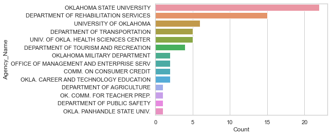

```python
# Summarize the count statistics by agency_name in df_count
df_count = outl_df['Agency_Name'].value_counts()
df_count = pd.DataFrame(df_count).reset_index()
df_count.columns = ['Agency_Name','Count']

fig = px.bar(df_count, x='Agency_Name', y='Count', color = 'Agency_Name', width=1000, height=400)
import seaborn as sns
sns.set_theme(style="whitegrid")
sns.barplot(y="Agency_Name", x="Count", data=df_count[0:20])
```

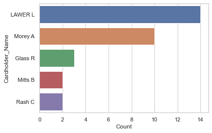

```python
# Summarize the count statistics by agency_name in df_count
df_count = outl_df['Cardholder_Name'].value_counts().head() # top five cardholders in abnormal cluster
df_count = pd.DataFrame(df_count).reset_index()
df_count.columns = ['Cardholder_Name','Count']

fig = px.bar(df_count, x='Cardholder_Name', y='Count', color = 'Cardholder_Name', width=1000, height=400)
import seaborn as sns
sns.set_theme(style="whitegrid")
sns.barplot(y="Cardholder_Name", x="Count", data=df_count[0:20])
```

#### Conclusion:

- Using KNNs and aggragate average method to train the data, the model fount out 69 anomaly data point in test data. The average distance is large in the abnormal cluster than normal data cluster.
- The 14 features are meaningful features to detect outliers.
- Department of rehabilation services might have many fraudulent transactions.
- LAWER L and Morey A might be the corporate card abusers in their agencies.

## Section 5. Summary

- For this project, I come up with 14 derived features to build a unsupervised k-nearest neighbors model to detect fradulent credit card transactions.
- From EDA, we can tell that the top two agencies with the most transactions are Oklahoma State University and University of Oklahoma. The top two most transacted merchant categories are stationery and book stores. And the month has the most transactions is October.
- Getting the inspirations from reserach papers and prof, I use grouping aggregation, different time periods and ratios to create 14 features. Group by agency and merchant or group by agency and cardholder, and consider the effect of monthly transaction pattern and transactions on the same day. Based on practitioner literature and intuition, the larger the ratio, the higher the likelihood of the transaction being fradulent for each of the features.
- To find out outliers and anomaly transactions, I built knns model (an unsupervised machine learning technique) using 14 derived features and group the data points into two clusters (one is normal transactions and the other is abnormal transactions). Before modeling, split the train and test by 80/20, train the model using training dataset and apply the model to test dataset to find out outliers in the test dataset. I aggreagte 5 knn models to achieve model stability, reduce overfitting risk, and then use average method to compute outlier scores. Using boundary outlier score of 1, the model identifies 69 likely fraudulent transactions in the test dataset. The 14 features are useful in detecting the anomaly data points. Finally, I explore a little about the abnormal transactions in the test dataset.

### Limitation & future study

- Due to high volume data and long training time, I just build 5 knns and use average method to reach the conclusion. The model can be improved by testing different n knns and aggregate with different methods.